# Necessary conditions analysis (NCA)

Stef Meliss

2026-07-20

# Conditions: Framework for Teaching (FFT)

FFT is an observational protocol designed to measure components of instruction that reflect a constructivist view of teaching. The instrument was used in the MET Study to code instruction in all English and math classrooms at grades 4-9 using the domains “Classroom Environment” and “Instruction”. Each of these domains, in turn, is measured by a number of indicators.

- The domain *Classroom Environment* is measured along four indicators: creating an environment of respect and rapport; establishing a culture for learning; managing classroom procedures; and managing student behaviour.
- The domain *Instruction* also is measured along four indicators: communicating with students; using questioning and discussion techniques, engaging students in learning, and using assessment in instruction.

| Item | Description | Domain |
| --- | --- | --- |
| FFT_MSB | Managing student behaviour | Classroom environment (FFT_CEV) |
| FFT_MCP | Managing classroom procedures | Classroom environment (FFT_CEV) |
| FFT_CERR | Creating an environment of respect and rapport | Classroom environment (FFT_CEV) |
| FFT_ECL | Establishing a culture for learning | Classroom environment (FFT_CEV) |
| FFT_UQDT | Using questioning and discussion techniques | Instruction (FFT_INS) |
| FFT_CS | Communicating with students | Instruction (FFT_INS) |
| FFT_ESL | Engaging students in learning | Instruction (FFT_INS) |
| FFT_UAI | Using assessment in instruction | Instruction (FFT_INS) |

FFT scoring is done using a detailed scoring rubric. However, unlike the other observation protocols used in the MET Study, raters use this rubric only once for each video, that is, a video scored with the FFT protocol will have only 1 score per video on each of the dimensions just described. In the MET Study, raters did not watch an entire video, however. Instead, raters watched for 15 minutes at the beginning of the video and then ten additional minutes at the 25-35 minute mark. They then scored the video as a single segment. Each indicator of the FFT protocol was scored on a 4-point scale ranging from unsatisfactory, to basic, to proficient, to distinguished, and for each indicator, a detailed scoring rubric described the kind of evidence appropriate for assigning a particular score.

For each observer score $o$ at classroom section $k$ taught by teacher $j$ at time $t$, we estimated its reliability $\text{Reliability}_{ojkt}$ using the following formula:

$$\text{Reliability}_{ojkt} = \frac{\text{% teacher}}{\text{% teacher} +
\frac{\text{% section}}{\text{# of sections}_{ojkt}} + \frac{\text{%
lessons}}{\text{# of lessons}_{ojkt}} + \frac{\text{% raters}}{\text{#
of raters}_{ojkt}} + \frac{\text{% residual}}{\text{total # of scores
per teacher}_{ojkt}}}$$

Percentages ($\text{%}$) were based on the variance decomposition reported in Gates Foundation (2012) whereas counts ($\text{#}$) were derived based on the number of segments averaged.

The reliability coefficients $\text{Reliability}_{ojkt}$ were then used to adjust observer score $o$ at classroom section $k$ taught by teacher $j$ at time $t$ towards the mean based on the reliability of each score using the following formula for reliability-based shrinkage:

$$\text{Score}_{adj, ojkt} = \overline{\text{Score}}_{ot} +
\text{Reliability}_{ojkt} * (\overline{\text{Score}}_{ot} -
\text{Score}_{ojkt})$$

To better understand the results, we also standardised the adjusted observation scores.
$$\text{Score}_{adj, std, ojkt} = \frac{\text{Score}_{adj, ojkt} -
\overline{\text{Score}}_{adj, ot}}{SD_{adj, ot}}$$

# Outcomes: Value-added measures

At grades 4-8, pupil learning was measured by state mathematics assessments as well as the Balanced Assessment in Mathematics (BAM) administered directly by MET researchers. BAM is an open ended assessment that seeks to measure pupils’ capacities in the following areas: modelling/formulating problems; transforming/manipulating mathematical formalisms; inferring/drawing conclusions; and communicating about mathematics. Each assessment form contains four to five assessment tasks and requires 50-60 minutes to complete. Concerns about generalisability led the MET researchers to administer three different forms of the BAM (from the relevant grade levels tests for 2003, 2004 and 2005) in each classroom. Thus, all pupils in a classroom (or class section) did not take the same test.

MET researchers used pupil test scores to construct “value-added” measures of teaching effectiveness for individual teachers. The teachers provided information to indicate the percentage of instructional responsibility for all pupils in a MET classroom each time pupil data was collected. This information was connected with the pupil achievement data to estimate value-added measures of teaching effectiveness based on a single outcome (e.g., the state Mathematics test, or the BAM). MET researchers estimated value-added models for each outcome separately by grade and district, so that all value-added estimates are not just test-specific, but also grade and district specific.

$$Y_{sit} = X_{it}\beta + \overline{X}_{jkt}\gamma + \theta Z_{si(t-1)} +
\lambda \overline{Z}_{sjk(t-1)} + \epsilon_{sit}$$

where:  
- $Y_{sit}$ is one of the achievement outcomes for pupil $i$ on test $s$ in the current school year $t$ (rank-based z-scores)  
- $X_{it}$ is a vector of pupil background variables for pupil $i$ at time $t$  
- $\overline{X}_{jkt}$ is a vector of the same pupil background variables, aggregated at section $k$ taught by teacher $j$ in which the pupil $i$ was enrolled at time $t$  
- $Z_{si(t-1)}$ is pupil $i$’s prior test score (in the same subject as test $s$) at year $t-1$  
- $\overline{Z}_{sjk(t-1)}$ is the prior test score (in the same subject as test $s$) at year $t-1$, aggregated at section $k$ taught by teacher $j$ in which the pupil $i$ was enrolled  
- $\epsilon_{sit}$ is a residual for pupil $i$ on test $s$ in year $t$

There is also another set of value-added measures available that does not control for classroom-level aggregates:

$$Y_{sit} = X_{it}\beta + \theta
Z_{si(t-1)} + \epsilon_{sit}$$

The residuals $\epsilon_{sit}$ were used as the basis for constructing value-added scores. The value-added score averages residuals for test $s$ for the section $k$ taught by teacher $j$ in which the pupil $i$ was enrolled at time $t$. Standard errors (SEs) for each teacher’s VAM are calculated as the SD of the residuals for a class section $k$ divided by the square root of the number of pupils residuals included in the classroom average.

$$\text{VAM}_{sjkt} = \bar{\epsilon}_{sjkt} = \frac{1}{n} \sum_{i =
1}^{n} \epsilon_{sit}$$

$$\text{SE}_{sjkt} = \frac{\text{SD}_{sjkt}}{\sqrt{n}} =
\frac{\sqrt{\frac{1}{n-1} \sum_{i=1}^{n} (\epsilon_{sit} -
\bar{\epsilon}_{sjkt}} )^2 }{\sqrt{n}}$$

For each $\text{VAM}_{sjkt}$, we estimated its reliability $\text{Reliability}_{sjkt}$ using the pooled variance $S^2_{pooled, st}$ of all $\text{VAM}_{sjkt}$ and the error variance $\text{S}_{error, sjkt}^2$ of each $\text{VAM}_{sjkt}$:

$$\text{Reliability}_{sjkt} = \frac{ S^2_{pooled, st} }{S^2_{pooled, st} +
\text{S}_{error, sjkt}^2}$$
The $S^2_{pooled, st}$ was computed as the variance across all classroom-level $\text{VAM}_{sjkt}$ for test $s$ at time $t$. The $\text{S}_{error, sjkt}^2$ was computed by squaring the $\text{SE}_{sjkt}$ reported for each $\text{VAM}_{sjkt}$.

$$S^2_{pooled, st} = \frac{1}{m-1} \sum_{k=1}^{m} (\text{VAM}_{sjkt} -
\overline{\text{VAM}}_{st})^2$$
where $\overline{\text{VAM}}_{st} = \frac{1}{m} \sum_{k=1}^{m} \text{VAM}_{sjkt}$.

$$\text{S}_{error, sjkt}^2 = \text{SE}_{sjkt}^2$$

The reliability coefficients $\text{Reliability}_{sjkt}$ were then used to adjust the $\text{VAM}_{sjkt}$ towards the mean using the following formula for reliability-based shrinkage:

$$\text{VAM}_{adj, sjkt} = \overline{\text{VAM}}_{st} +
\text{Reliability}_{sjkt} * (\overline{\text{VAM}}_{st} -
\text{VAM}_{sjkt})$$

To facilitate comparability, we standardised unadjusted and adjusted VAMs $\text{VAM}_{sjkt}$ and $\text{VAM}_{adj, sjkt}$ by subtracting the their means and dividing by their SD.

$$\text{VAM}_{std, sjkt} = \frac{\text{VAM}_{sjkt} -
\overline{\text{VAM}}_{st}}{SD_{st}}$$
$$\text{VAM}_{adj, std, sjkt} = \frac{\text{VAM}_{adj, sjkt} -
\overline{\text{VAM}}_{adj, st}}{SD_{adj, st}}$$

# Necessary Condition Analysis (NCA)

Necessary Condition Analysis (NCA: Dul, 2016) is a method to identify conditions that must be present for a particular outcome to occur, but alone may not be sufficient to guarantee that outcome. The focus is the determine whether the absence of a condition prevents the desired outcome, highlighting constraints rather than drivers of success.

In traditional methods (e.g., multiple linear regression), it is assumed that each predictor additively influences the outcome. If one predictor is zero, the value of the outcome will be reduced unless the values of other predictors can compensate. In NCA, in comparison, the absence of a necessary condition results in outcome failure, independently of the value of the other predictors. Hence, in NCA, the aim is to search for empty areas in scatter plots between outcome and NCA predictor to draw a “ceiling line” to separate full and empty areas in the data. The presence of an empty zone is an indication of a necessary condition. This ceiling line marks the maximum possible value of the outcome for each value of the predictor to identify boundaries beyond which the outcome cannot go. In other words, a certain desired level of the outcome $Y = Y_C$ can only be achieved if $X \ge X_C$. This clearly differs from the concept of a regression line that shows the average relationship between two variables, typically by minimising the distance between the line and all data points.

Scatter plots are the starting point for NCA where the potential necessary condition is plotted on the x axis against the outcome on the y axis. Then a ceiling line is drawn to separate the ‘empty’ (or ceiling) zone in the left corner from the ‘full’ zone. The aim is to make the ceiling zone as large as possible without allowing any observations in the ceiling zone above the ceiling line. However, this requires a trade-off between the size of the ceiling zone and the number of observations in the ceiling zone (referred to as outliers or exceptions).

There are two classes of techniques to draw ceiling lines:

- Ceiling envelopment (CE)
- Ceiling regression (CR)

**Ceiling envelopment (CE)** is a non-parametric technique. A piecewise linear or stepwise ceiling line is drawn by connecting the highest observed values of the outcome for each value of the potential necessary condition. The resulting line ‘envelops’ the data from above, showing the empirical limit of the outcome value for each value of the necessary condition. There are hence no observations above the ceiling line. The *CE Free Disposal Hull (FDH) method* forms the ceiling by connecting the highest outcome values with horizontal and vertical segments, resulting in stepwise linear boundaries. There are no restrictions on the shape of the line, allowing for abrupt changes and flat sections. It is hence flexible but sensitive to outliers. The *CE Varying returns to scale (VRS) method* uses the highest observed outcome values but connects them with straight lines to create piecewise linear convex boundaries. This allows the slope of the ceiling to change across intervals, reflecting the possibility that the relationship between necessary condition and outcome may vary at different levels. The CE-VRS method assumes that the ceiling line is convex. CE-VRS produces smoother lines compared to CE-FDH, accommodating varying returns to scale without assuming a fixed rate of change. However, CE-FDH does not require convexity of the ceiling function and is therefore preferred over CE-VRS as the default CE technique for NCA (Dul, 2016).

**Ceiling regression (CR)** is a parametric technique. It fits a regression linear regression line through the points connecting the linear pieces of the CE ceiling line. The CR ceiling line is smooth and less sensitive to outliers compared the CE ceiling lines. The smoothing approach often leads to some observations in the ceiling zone as well as a smaller ceiling zone. CR methods introduce a parametric model to summarise the relationship between the necessary condition and outcome, while allowing for further modeling and comparison of ceiling lines. The *CR-FDH method* fits a regression model to the stepwise boundary formed by the CE-FDH approach. The *CR-VRS method* fits a regression model to the piecewise linear boundary formed by the CE-VRS approach. Similarly as above, CR-FDH is preferred over CR-VRS.

Parameters of interest in NCA:

- $\text{Scope} = (X_{max}-X_{min}) \times (Y_{max}-Y_{min})$ (empirical area of possible combinations between outcome and necessary condition, given the minimum and maximum observed values)
- $\text{Ceiling zone}$ (size of the ceiling zone)
- $\text{Effect size} = \frac{\text{Ceiling zone}}{\text{Scope}}\%$ (represents how much of a given value of the necessary condition constrains the outcome)
- $\text{Accuracy of ceiling line} = \frac{N_{\text{Observations on or below the ceiling line}}}{N_{\text{Total observations}}} * 100\%$ (Benchmark is 95%)
- $N_{\text{Observations above the ceiling line}}$
- $\text{Fit}$ (closeness of the selected ceiling line to the CE-FDH line)
- $\text{p value}$ (estimated using statistical approximate permutation tests, see Dul et al., 2020)
- $\text{p accuracy}$ (estimated error of the p value, smaller error as number of resamples increases)
- $\text{Slope}$ and $\text{Intercept}$ (parameters to describe straight ceiling line)
- $\text{Absolute inefficiency}$ (total xy-space where X does not constrain Y and Y is not constraint by X)
- $\text{Relative inefficiency}$ (total xy-space where X does not constrain Y and Y is not constraint by X as percentage of $\text{Scope}$)
- $\text{Condition inefficiency} = (X_{\text{High}}-X_{\text{cmax}}) / (X_{\text{High}}-X_{\text{Low}}) \times 100\%$ (range of X (as percentage of total range of X) where X does not constrain Y, i.e., percentage of X range where there is no ceiling line)
- $\text{Outcome inefficiency} = (Y_{\text{cmin}}-Y_{\text{Low}}) / (Y_{\text{High}}-Y_{\text{Low}}) \times 100\%$ (range of Y (as percentage of total range of Y) where Y is not constraint by X, i.e., percentage of Y range where there is no ceiling line)

The bottleneck table shows which level of the necessary condition is necessary for each level of outcome. For a given outcome value, it shows the minimum required values of the independent variables.

# Year 2 data

In this set of analysis, we focus on data on the **focal class sections** taught by MET LDB mathematics teachers in Year 2 (that is, 2011). During the second year of the study, the intention was for all teachers to be randomly assigned to class sections and we focus on those class sections where this was possible. We further limit the analysis to the focal class sections for which there are observations from the FFT, CLASS and MQI observation instruments as well as teacher-value added outcome measures for the state maths test (aligned with curriculum in grades 4-8) and the Balanced Assessment of Mathematics (BAM, grades 4-8). At grade 9, ACT QualityCore Assessments were the only achievement tests administered to the pupils. Data from grade 9 were hence omitted.

> All analyses included here are at the **class section level**. The total sample is described below.

## Sample demographics

Data is available for 642 classrooms, taught by 642 teachers, serving 16370 pupils in 175 schools. The average class size is 25.5 (SD = 6.78). **Class sizes range from 9 to 61 pupils.**

Grade and subject level of scored classroom sections

SUBJECTLEVEL

Number of class sections

Number of pupils

2. Gr4-5ELA+Math

291

7703

3. Gr4-5Math

70

1453

5. Gr6-8ELA+Math

4

115

6. Gr6-8Math

277

7099

Note. State maths test and BAM were not administered in grade 9, leading to an exclusion of all grade 9 class sections.

Most teachers in elementary grades (4 and 5) were subject matter generalists, teaching multiple subjects to a single group of pupils. Most teachers in middle grades (6 to 8) were specialist teachers, teaching the same subject to multiple groups of pupils.

Grade level of scored classroom sections

| GRADE | Number of class sections | Number of pupils |
| --- | --- | --- |
| 4 | 171 | 4331 |
| 5 | 190 | 4825 |
| 6 | 105 | 2548 |
| 7 | 84 | 2232 |
| 8 | 92 | 2434 |

Note. State maths test and BAM were not administered in grade 9, leading to an exclusion of all grade 9 class sections.  
Most teachers in elementary grades (4 and 5) were subject matter generalists, teaching multiple subjects to a single group of pupils. Most teachers in middle grades (6 to 8) were specialist teachers, teaching the same subject to multiple groups of pupils.

Pupil-level characteristics

| Characteristic | Description | Weighted mean | Weighted SD | N |
| --- | --- | --- | --- | --- |
| AVERAGEAGE | Average age | 10.45 | 1.49 | 642 |
| GIFTED | % gifted | 0.07 | 0.16 | 642 |
| MALE | % male | 0.50 | 0.10 | 642 |
| SPED | % special education status | 0.09 | 0.10 | 642 |
| ELL | % English language learner status | 0.13 | 0.17 | 642 |
| FRL | % Free or reduced lunch price status | 0.56 | 0.31 | 491 |
| RACEOTHER | % Other ethnic background | 0.02 | 0.04 | 642 |
| ASIAN | % Asian | 0.07 | 0.13 | 642 |
| HISPANIC | % Hispanic | 0.29 | 0.27 | 642 |
| BLACK | % Black | 0.38 | 0.35 | 642 |
| WHITE | % White | 0.23 | 0.28 | 642 |
| DISABILITY | % disability status | 0.13 | 0.10 | 106 |

Note. Data is available for 642 classrooms, taught by 642 teachers, serving 16370 pupils in 175 schools. The number of classrooms with non-missing data for each characteristic is included in the table. Weighted means and SDs are calculated using the class size. Weighted statistics reflect the distribution of each characteristic across all pupils in the sample.

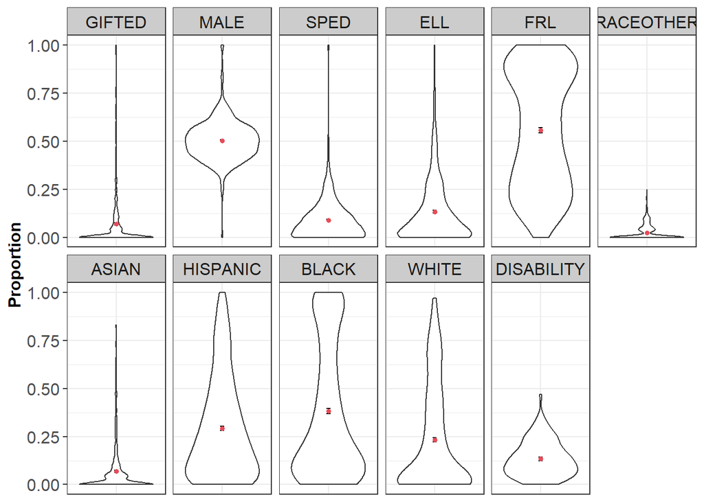

Note. The coral dots represent the weighted means. Error bars represent +/- 1 SE.

Descriptive information on teachers teaching the class sections

| Characteristic | Count | Non-missing observations | Proportion of non-missing observations | Proportion of sample size |
| --- | --- | --- | --- | --- |
| DAD_MALE | 108 | 622 | 0.174 | 0.168 |
| DAD_WHITE | 358 | 620 | 0.577 | 0.558 |
| DAD_BLACK | 216 | 620 | 0.348 | 0.336 |
| DAD_HISPANIC | 34 | 620 | 0.055 | 0.053 |
| DAD_RACEOTHER | 12 | 620 | 0.019 | 0.019 |
| DAD_MASTERSPLUS | 194 | 480 | 0.404 | 0.302 |
| DAD_YRSEXP_NEW | 36 | 230 | 0.157 | 0.056 |
| DAD_YRSEXP_EARLY | 49 | 230 | 0.213 | 0.076 |
| DAD_YRSEXP_EST | 51 | 230 | 0.222 | 0.079 |
| DAD_YRSEXP_EXP | 57 | 230 | 0.248 | 0.089 |
| DAD_YRSEXP_HIGH | 37 | 230 | 0.161 | 0.058 |
| DAD_YRSEXPDIST_NEW | 102 | 469 | 0.217 | 0.159 |
| DAD_YRSEXPDIST_EARLY | 141 | 469 | 0.301 | 0.220 |
| DAD_YRSEXPDIST_EST | 118 | 469 | 0.252 | 0.184 |
| DAD_YRSEXPDIST_EXP | 78 | 469 | 0.166 | 0.121 |
| DAD_YRSEXPDIST_HIGH | 30 | 469 | 0.064 | 0.047 |

Note. This table indicates the counts of teachers in the analytical sample that indicated a certain demographic characteristic. The information may be missing for some teachers in the total sample of 642 teachers.  
Experience was grouped as NEW = [0, 2] years, EARLY = (2, 5] years, EST = (5, 10] years, EXP = (10, 20] years, HIGH = (20, Inf) years.

Descriptive information on teachers teaching the class sections (continued)

| Characteristic | Mean | SD | N |
| --- | --- | --- | --- |
| DAD_YRSEXP | 11.052 | 9.432 | 230 |
| DAD_YRSEXPDIST | 7.265 | 6.872 | 469 |
| DAD_YRSEXP_DIFF | 1.957 | 4.471 | 230 |
| FFT_CEV_adj | 2.667 | 0.195 | 642 |
| VA_MATH_adj | -0.004 | 0.183 | 642 |
| VA_BAM_adj | 0.002 | 0.167 | 642 |

Note. This table indicates mean and SD of teachers in the analytical sample that indicated a certain demographic characteristic. The information may be missing for some teachers in the total sample of 642 teachers.  
DAD_YRSEXP_DIFF is the difference between total teaching experience DAD_YRSEXP and teaching experience in the district DAD_YRSEXPDIST.  
CEV, VA_MATH & VA_BAM represent teacher-level aggregates. FFT scores were adjusted at teacher level. VAMs were adjusted at section level and then aggregated at the teacher level using weighted means, accounting for the pupils included in the section-level VAMs.

Correlation of teaching experience with necessary condition and outcomes

| x | y | cor | ci_l | ci_u | df | t | p | N |
| --- | --- | --- | --- | --- | --- | --- | --- | --- |
| DAD_YRSEXP | FFT_CEV_adj_std | 0.091 | -0.038 | 0.218 | 228 | 1.387 | 0.167 | 230 |
| DAD_YRSEXP | FFT_MSB_adj_std | 0.063 | -0.067 | 0.191 | 228 | 0.959 | 0.339 | 230 |
| DAD_YRSEXP | FFT_MCP_adj_std | 0.084 | -0.046 | 0.211 | 228 | 1.273 | 0.204 | 230 |
| DAD_YRSEXP | FFT_CERR_adj_std | 0.078 | -0.052 | 0.205 | 228 | 1.183 | 0.238 | 230 |
| DAD_YRSEXP | FFT_ECL_adj_std | 0.094 | -0.036 | 0.220 | 228 | 1.423 | 0.156 | 230 |
| DAD_YRSEXP | VA_MATH_adj_std | 0.054 | -0.076 | 0.182 | 228 | 0.819 | 0.413 | 230 |
| DAD_YRSEXP | VA_BAM_adj_std | 0.119 | -0.010 | 0.245 | 228 | 1.816 | 0.071 | 230 |
| DAD_YRSEXPDIST | FFT_CEV_adj_std | 0.048 | -0.043 | 0.138 | 467 | 1.033 | 0.302 | 469 |
| DAD_YRSEXPDIST | FFT_MSB_adj_std | 0.054 | -0.036 | 0.144 | 467 | 1.174 | 0.241 | 469 |
| DAD_YRSEXPDIST | FFT_MCP_adj_std | 0.037 | -0.054 | 0.127 | 467 | 0.796 | 0.426 | 469 |
| DAD_YRSEXPDIST | FFT_CERR_adj_std | 0.030 | -0.061 | 0.120 | 467 | 0.650 | 0.516 | 469 |
| DAD_YRSEXPDIST | FFT_ECL_adj_std | 0.048 | -0.043 | 0.138 | 467 | 1.039 | 0.299 | 469 |
| DAD_YRSEXPDIST | VA_MATH_adj_std | -0.005 | -0.096 | 0.085 | 467 | -0.113 | 0.910 | 469 |
| DAD_YRSEXPDIST | VA_BAM_adj_std | 0.015 | -0.075 | 0.106 | 467 | 0.331 | 0.741 | 469 |

Note. Data on DAD_YRSEXP is available for 230 teachers. Data on DAD_YRSEXPDIST is available for 469 teachers.

Underlying count data for figure - Years of teaching experience

| YRSEXP | Domain | Mean | SD | N |
| --- | --- | --- | --- | --- |
| [0, 2] | CEV | -0.34 | 1.06 | 36 |
| [0, 2] | MATH | -0.09 | 0.88 | 36 |
| [0, 2] | BAM | -0.24 | 0.79 | 36 |
| (2, 4] | CEV | -0.12 | 1.20 | 32 |
| (2, 4] | MATH | -0.02 | 0.72 | 32 |
| (2, 4] | BAM | -0.09 | 0.74 | 32 |
| (4, 6] | CEV | 0.10 | 0.99 | 32 |
| (4, 6] | MATH | 0.24 | 0.91 | 32 |
| (4, 6] | BAM | 0.03 | 0.95 | 32 |
| (6, 8] | CEV | 0.09 | 0.95 | 19 |
| (6, 8] | MATH | 0.17 | 0.70 | 19 |
| (6, 8] | BAM | 0.17 | 0.81 | 19 |
| (8, 10] | CEV | 0.19 | 0.76 | 17 |
| (8, 10] | MATH | -0.33 | 0.60 | 17 |
| (8, 10] | BAM | 0.14 | 0.94 | 17 |
| (10, 12] | CEV | 0.02 | 0.83 | 14 |
| (10, 12] | MATH | -0.26 | 0.77 | 14 |
| (10, 12] | BAM | -0.08 | 1.03 | 14 |
| (12, 14] | CEV | -0.28 | 0.93 | 15 |
| (12, 14] | MATH | -0.15 | 0.67 | 15 |
| (12, 14] | BAM | -0.34 | 1.05 | 15 |
| (14, 16] | CEV | 0.18 | 1.06 | 10 |
| (14, 16] | MATH | -0.09 | 0.51 | 10 |
| (14, 16] | BAM | -0.28 | 1.03 | 10 |
| (16, 18] | CEV | 0.09 | 0.85 | 13 |
| (16, 18] | MATH | -0.04 | 0.94 | 13 |
| (16, 18] | BAM | -0.22 | 0.99 | 13 |
| (18, Inf) | CEV | 0.05 | 0.72 | 42 |
| (18, Inf) | MATH | 0.03 | 0.93 | 42 |
| (18, Inf) | BAM | 0.24 | 0.78 | 42 |

#### **Figure**

#### *Relationship between teaching experience, necessary condition and outcomes*

[figure not shown]

Underlying count data for figure - Years of teaching experience in dictrict

| YRSEXPDIST | Domain | Mean | SD | N |
| --- | --- | --- | --- | --- |
| [0, 2] | CEV | -0.08 | 1.13 | 102 |
| [0, 2] | MATH | -0.10 | 1.06 | 102 |
| [0, 2] | BAM | -0.13 | 1.00 | 102 |
| (2, 4] | CEV | 0.00 | 1.05 | 88 |
| (2, 4] | MATH | 0.21 | 1.21 | 88 |
| (2, 4] | BAM | 0.17 | 1.00 | 88 |
| (4, 6] | CEV | -0.11 | 0.96 | 87 |
| (4, 6] | MATH | -0.05 | 0.90 | 87 |
| (4, 6] | BAM | 0.00 | 0.97 | 87 |
| (6, 8] | CEV | -0.24 | 1.29 | 50 |
| (6, 8] | MATH | -0.14 | 0.92 | 50 |
| (6, 8] | BAM | -0.23 | 1.05 | 50 |
| (8, 10] | CEV | 0.25 | 0.76 | 34 |
| (8, 10] | MATH | -0.26 | 0.98 | 34 |
| (8, 10] | BAM | -0.04 | 1.19 | 34 |
| (10, 12] | CEV | 0.00 | 0.82 | 28 |
| (10, 12] | MATH | 0.02 | 1.10 | 28 |
| (10, 12] | BAM | 0.24 | 1.13 | 28 |
| (12, 14] | CEV | -0.03 | 0.83 | 17 |
| (12, 14] | MATH | 0.27 | 1.05 | 17 |
| (12, 14] | BAM | 0.01 | 1.00 | 17 |
| (14, 16] | CEV | 0.11 | 1.10 | 15 |
| (14, 16] | MATH | 0.05 | 0.84 | 15 |
| (14, 16] | BAM | 0.33 | 1.28 | 15 |
| (16, 18] | CEV | -0.13 | 0.97 | 12 |
| (16, 18] | MATH | -0.48 | 1.15 | 12 |
| (16, 18] | BAM | -0.64 | 1.05 | 12 |
| (18, Inf) | CEV | 0.06 | 0.86 | 36 |
| (18, Inf) | MATH | 0.02 | 0.90 | 36 |
| (18, Inf) | BAM | 0.06 | 1.01 | 36 |

#### **Figure**

#### *Relationship between teaching experience in district, necessary condition and outcomes*

[figure not shown]

Underlying count data for figure - Years of teaching experience

| DAD_YRSEXP_GRP | Domain | Mean | SD | N |
| --- | --- | --- | --- | --- |
| [0, 2] | CEV | -0.34 | 1.06 | 36 |
| [0, 2] | MATH | -0.09 | 0.88 | 36 |
| [0, 2] | BAM | -0.24 | 0.79 | 36 |
| (2, 5] | CEV | -0.09 | 1.09 | 49 |
| (2, 5] | MATH | 0.02 | 0.83 | 49 |
| (2, 5] | BAM | -0.07 | 0.73 | 49 |
| (5, 10] | CEV | 0.17 | 0.93 | 51 |
| (5, 10] | MATH | 0.07 | 0.74 | 51 |
| (5, 10] | BAM | 0.14 | 0.96 | 51 |
| (10, 20] | CEV | 0.00 | 0.87 | 57 |
| (10, 20] | MATH | -0.19 | 0.73 | 57 |
| (10, 20] | BAM | -0.20 | 1.00 | 57 |
| (20, Inf) | CEV | 0.02 | 0.74 | 37 |
| (20, Inf) | MATH | 0.13 | 0.94 | 37 |
| (20, Inf) | BAM | 0.25 | 0.76 | 37 |

#### **Figure**

#### *Relationship between teaching experience, necessary condition and outcomes*

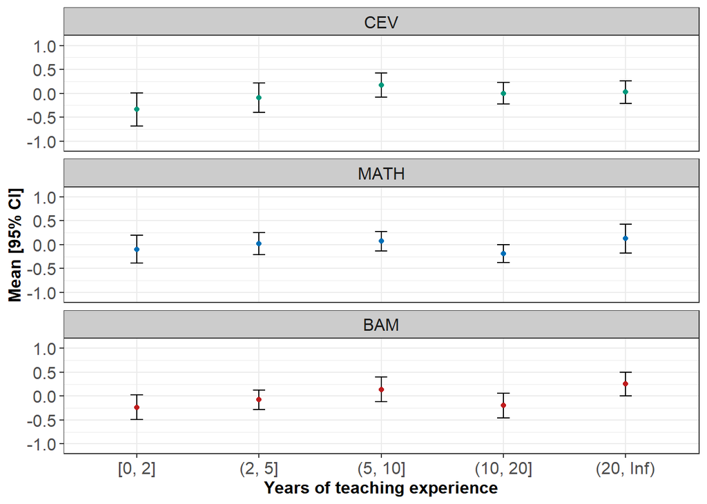

Underlying count data for figure - Years of teaching experience in the district

| DAD_YRSEXPDIST_GRP | Domain | Mean | SD | N |
| --- | --- | --- | --- | --- |
| [0, 2] | CEV | -0.08 | 1.13 | 102 |
| [0, 2] | MATH | -0.10 | 1.06 | 102 |
| [0, 2] | BAM | -0.13 | 1.00 | 102 |
| (2, 5] | CEV | -0.07 | 1.01 | 141 |
| (2, 5] | MATH | 0.09 | 1.08 | 141 |
| (2, 5] | BAM | 0.09 | 0.98 | 141 |
| (5, 10] | CEV | -0.03 | 1.09 | 118 |
| (5, 10] | MATH | -0.12 | 0.97 | 118 |
| (5, 10] | BAM | -0.09 | 1.09 | 118 |
| (10, 20] | CEV | 0.00 | 0.88 | 78 |
| (10, 20] | MATH | 0.00 | 1.02 | 78 |
| (10, 20] | BAM | 0.06 | 1.17 | 78 |
| (20, Inf) | CEV | 0.07 | 0.89 | 30 |
| (20, Inf) | MATH | 0.03 | 0.97 | 30 |
| (20, Inf) | BAM | 0.06 | 0.90 | 30 |

#### **Figure**

#### *Relationship between teaching experience in district, necessary condition and outcomes*

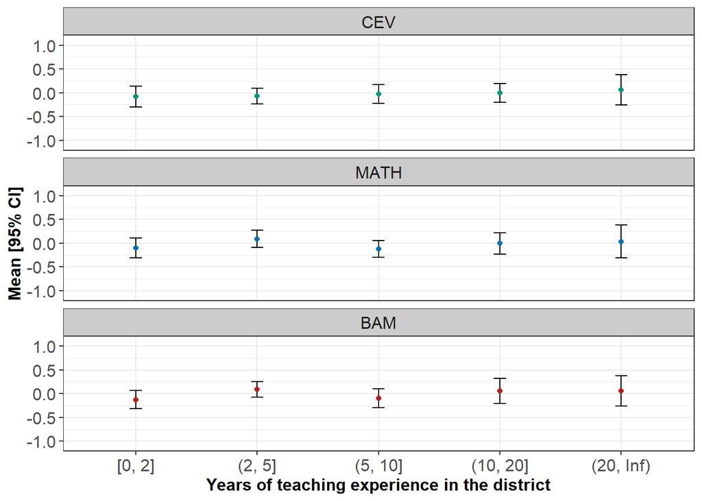

Within vs between school variation - section level

| Domain | avg_within_sd | within_var | between_sd | between_var | total_var | within_pct | between_pct |
| --- | --- | --- | --- | --- | --- | --- | --- |
| FFT_CEV_adj | 0.133 | 0.025 | 0.164 | 0.027 | 0.052 | 0.483 | 0.517 |
| VA_BAM_adj | 0.131 | 0.022 | 0.114 | 0.013 | 0.035 | 0.633 | 0.367 |
| VA_MATH_adj | 0.137 | 0.025 | 0.143 | 0.020 | 0.046 | 0.556 | 0.444 |

Note. Data is available for 642 classrooms. avg_within_sd is the average within-school SD. between_sd is the SD of school means. Classrooms were not aggregated at teacher-level before aggregating at school level.

Within vs between school variation - teacher level

| Domain | avg_within_sd | within_var | between_sd | between_var | total_var | within_pct | between_pct |
| --- | --- | --- | --- | --- | --- | --- | --- |
| FFT_CEV_adj | 0.133 | 0.025 | 0.164 | 0.027 | 0.052 | 0.483 | 0.517 |
| VA_BAM_adj | 0.131 | 0.022 | 0.114 | 0.013 | 0.035 | 0.633 | 0.367 |
| VA_MATH_adj | 0.137 | 0.025 | 0.143 | 0.020 | 0.046 | 0.556 | 0.444 |

Note. Data is available for 642 Teachers avg_within_sd is the average within-school SD. between_sd is the SD of school means. Classrooms were aggregated at teacher-level before aggregating at school level.

## Framework for Teaching (FFT)

Segment-level data is available for 3941 lesson segments.

Underlying count data for Observation score distributions figure

| item | domain | value | count |
| --- | --- | --- | --- |
| FFT_MSB | Classroom environment (FFT_CEV) | 1 | 82 |
| FFT_MSB | Classroom environment (FFT_CEV) | 2 | 850 |
| FFT_MSB | Classroom environment (FFT_CEV) | 3 | 2861 |
| FFT_MSB | Classroom environment (FFT_CEV) | 4 | 148 |
| FFT_MCP | Classroom environment (FFT_CEV) | 1 | 116 |
| FFT_MCP | Classroom environment (FFT_CEV) | 2 | 1009 |
| FFT_MCP | Classroom environment (FFT_CEV) | 3 | 2701 |
| FFT_MCP | Classroom environment (FFT_CEV) | 4 | 115 |
| FFT_CERR | Classroom environment (FFT_CEV) | 1 | 153 |
| FFT_CERR | Classroom environment (FFT_CEV) | 2 | 1030 |
| FFT_CERR | Classroom environment (FFT_CEV) | 3 | 2625 |
| FFT_CERR | Classroom environment (FFT_CEV) | 4 | 133 |
| FFT_ECL | Classroom environment (FFT_CEV) | 1 | 147 |
| FFT_ECL | Classroom environment (FFT_CEV) | 2 | 1529 |
| FFT_ECL | Classroom environment (FFT_CEV) | 3 | 2144 |
| FFT_ECL | Classroom environment (FFT_CEV) | 4 | 121 |
| FFT_UQDT | Instruction (FFT_INS) | 1 | 356 |
| FFT_UQDT | Instruction (FFT_INS) | 2 | 2327 |
| FFT_UQDT | Instruction (FFT_INS) | 3 | 1203 |
| FFT_UQDT | Instruction (FFT_INS) | 4 | 55 |
| FFT_CS | Instruction (FFT_INS) | 1 | 65 |
| FFT_CS | Instruction (FFT_INS) | 2 | 1447 |
| FFT_CS | Instruction (FFT_INS) | 3 | 2324 |
| FFT_CS | Instruction (FFT_INS) | 4 | 105 |
| FFT_ESL | Instruction (FFT_INS) | 1 | 143 |
| FFT_ESL | Instruction (FFT_INS) | 2 | 1927 |
| FFT_ESL | Instruction (FFT_INS) | 3 | 1750 |
| FFT_ESL | Instruction (FFT_INS) | 4 | 121 |
| FFT_UAI | Instruction (FFT_INS) | 1 | 233 |
| FFT_UAI | Instruction (FFT_INS) | 2 | 2210 |
| FFT_UAI | Instruction (FFT_INS) | 3 | 1423 |
| FFT_UAI | Instruction (FFT_INS) | 4 | 75 |

Note. The data shows the count of lesson video segments that have received a certain rating value for each domain of the FFT.

#### **Figure**

#### *Observation score distributions*

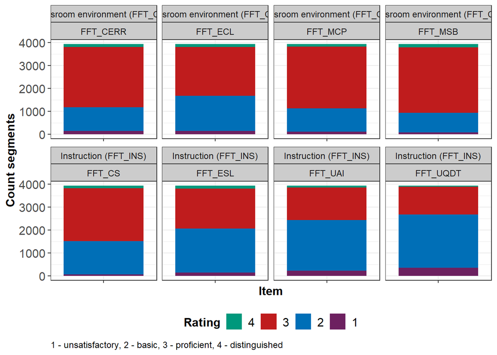

#### **Figure**

#### *Unadjusted observation scores aggregated at classroom level*

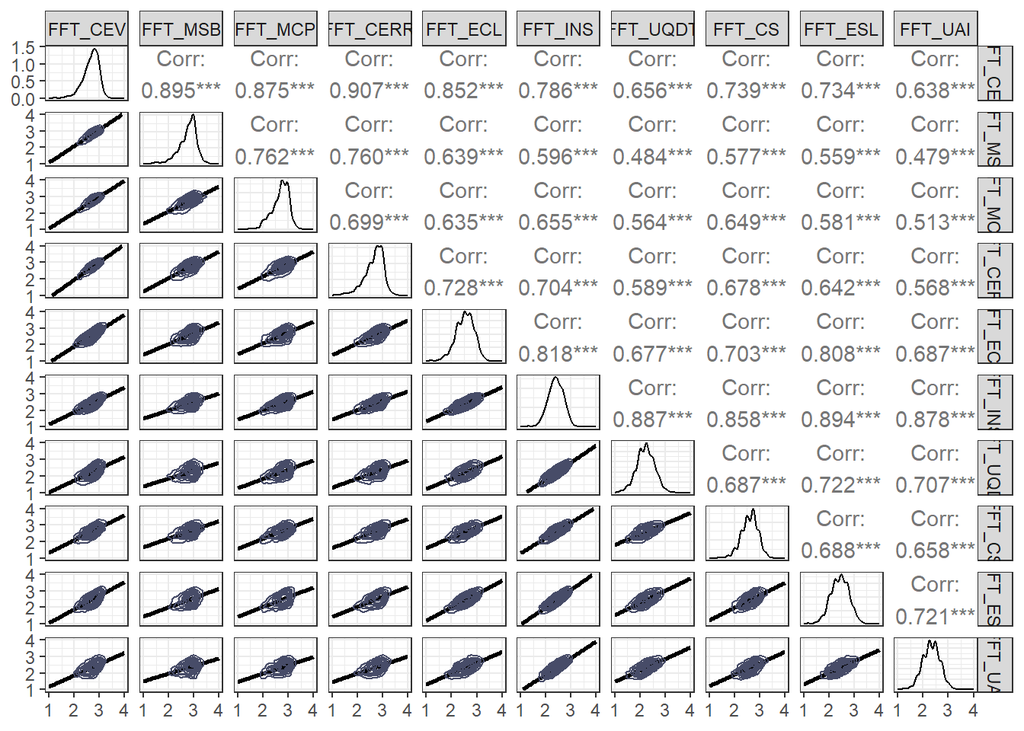

#### **Figure**

#### *Unadjusted observation scores aggregated at classroom level*

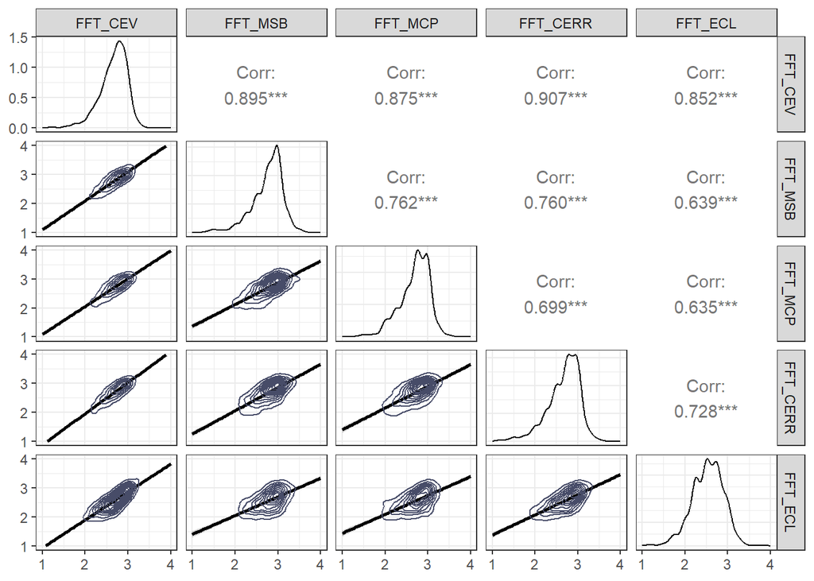

#### **Figure**

#### *Distribution of raw and adjusted observation scores*

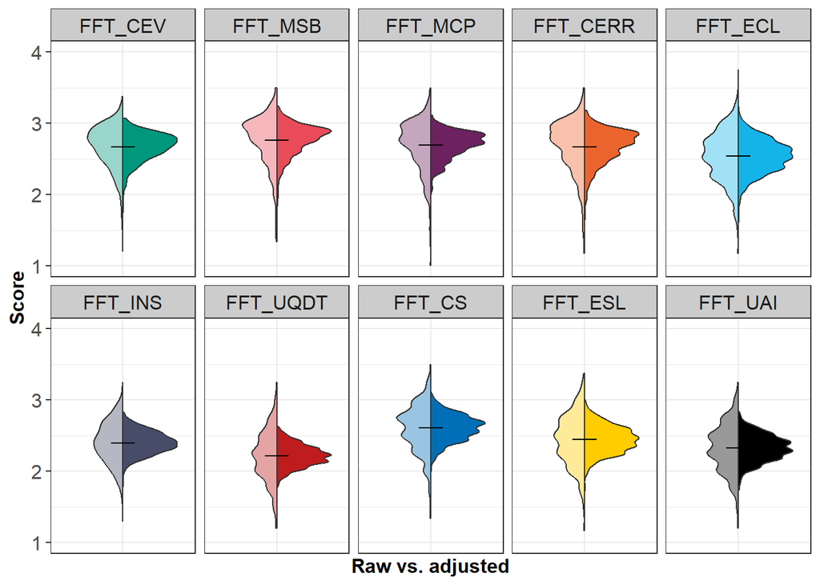

Raw observation scores

| Domain | Weighted mean | Weighted SD |
| --- | --- | --- |
| FFT_CEV | 2.66 | 0.32 |
| FFT_MSB | 2.76 | 0.35 |
| FFT_MCP | 2.69 | 0.34 |
| FFT_CERR | 2.67 | 0.37 |
| FFT_ECL | 2.54 | 0.36 |
| FFT_INS | 2.40 | 0.30 |
| FFT_UQDT | 2.22 | 0.34 |
| FFT_CS | 2.60 | 0.32 |
| FFT_ESL | 2.44 | 0.35 |
| FFT_UAI | 2.32 | 0.34 |

Note. Data from 642 classrooms is included. Weighted means and SDs are calculated using the class size. Weighted statistics reflect the distribution of each characteristic across all pupils in the sample.  
FFT_CEV and FFT_INS refer to the domain scores for classroom environment and instruction, respectively, computed as the mean of their indicators.

Adjusted observation scores

| Domain | Weighted mean | Weighted SD |
| --- | --- | --- |
| FFT_CEV | 2.67 | 0.20 |
| FFT_MSB | 2.76 | 0.22 |
| FFT_MCP | 2.69 | 0.19 |
| FFT_CERR | 2.67 | 0.24 |
| FFT_ECL | 2.55 | 0.23 |
| FFT_INS | 2.40 | 0.16 |
| FFT_UQDT | 2.22 | 0.15 |
| FFT_CS | 2.61 | 0.18 |
| FFT_ESL | 2.45 | 0.19 |
| FFT_UAI | 2.33 | 0.18 |

Note. Data from 642 classrooms is included. Weighted means and SDs are calculated using the class size. Weighted statistics reflect the distribution of each characteristic across all pupils in the sample.

#### **Figure**

#### *Relationship between raw and adjusted observation scores*

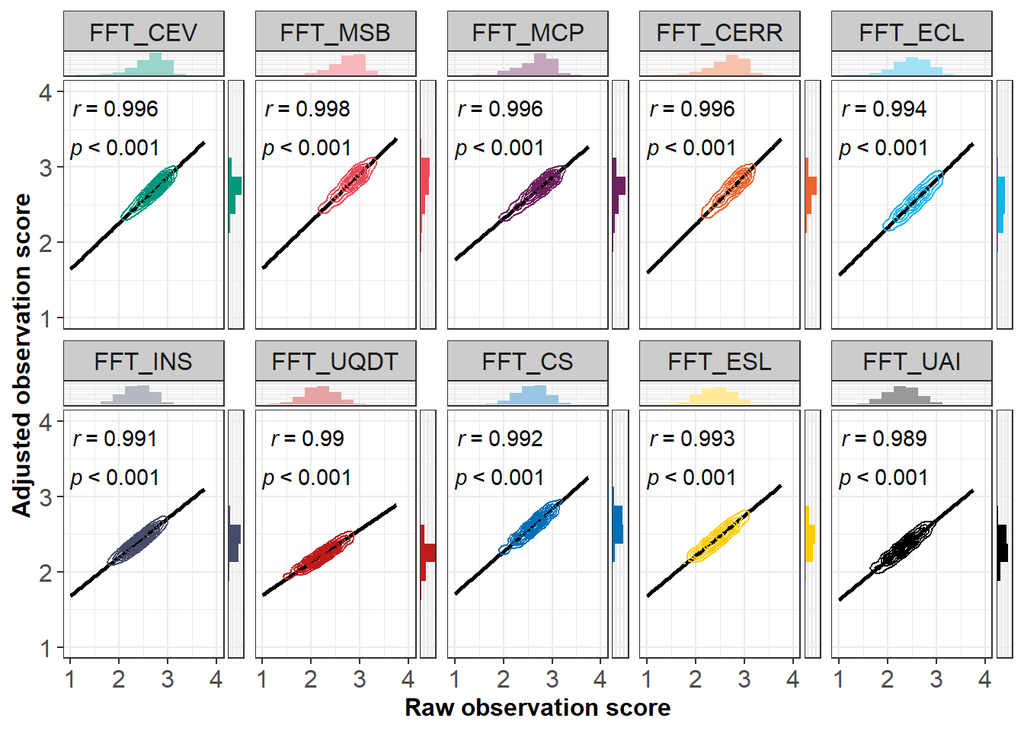

#### **Figure**

#### *Raw and adjusted observation scores*

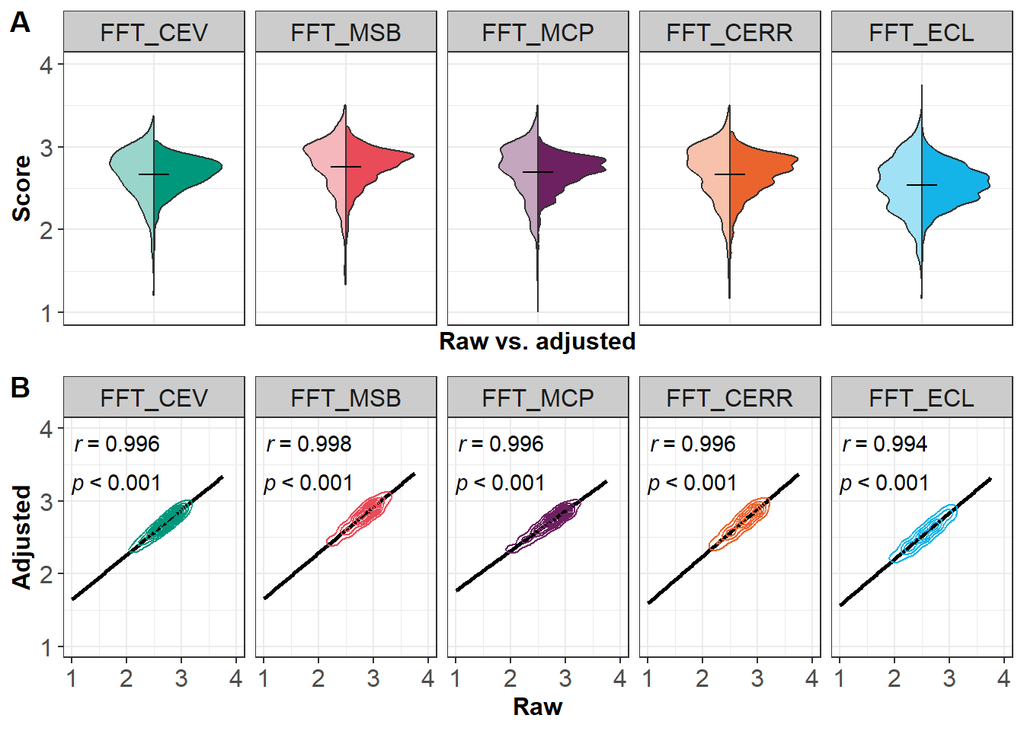

#### **Figure**

#### *Adjusted observation scores aggregated at classroom level*

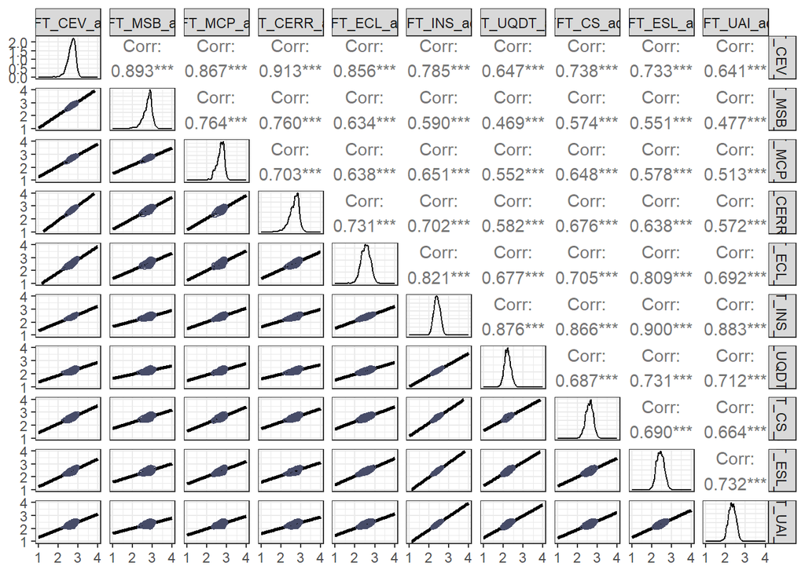

#### **Figure**

#### *Adjusted observation scores aggregated at classroom level*

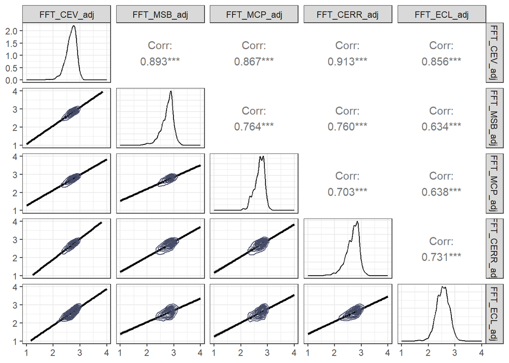

## Value-added measures

Value-added scores

| VAM | Weighted mean | Weighted SD | N Classrooms |
| --- | --- | --- | --- |
| VA_NOAGGR_MATH | -0.01 | 0.24 | 642 |
| VA_MATH | -0.01 | 0.23 | 642 |
| VA_MATH_std | -0.01 | 1.01 | 642 |
| VA_MATH_adj | -0.01 | 0.18 | 642 |
| VA_MATH_adj_std | -0.01 | 1.01 | 642 |
| VA_NOAGGR_BAM | 0.00 | 0.24 | 642 |
| VA_BAM | 0.00 | 0.23 | 642 |
| VA_BAM_std | 0.00 | 1.00 | 642 |
| VA_BAM_adj | 0.00 | 0.17 | 642 |
| VA_BAM_adj_std | 0.00 | 1.01 | 642 |

#### **Figure**

#### *Distribution of raw and adjusted VAMs*

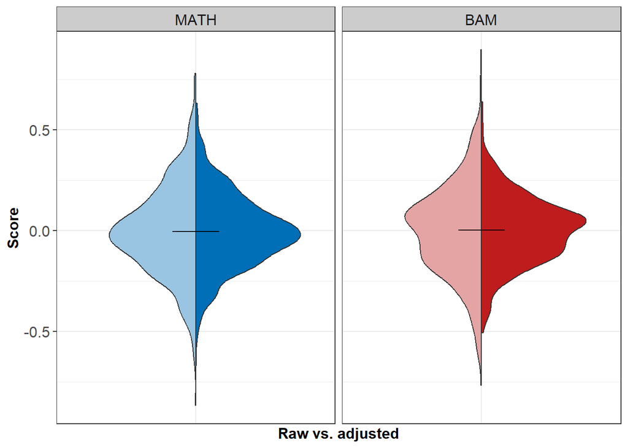

#### **Figure**

#### *Relationship between raw and adjusted VAMs*

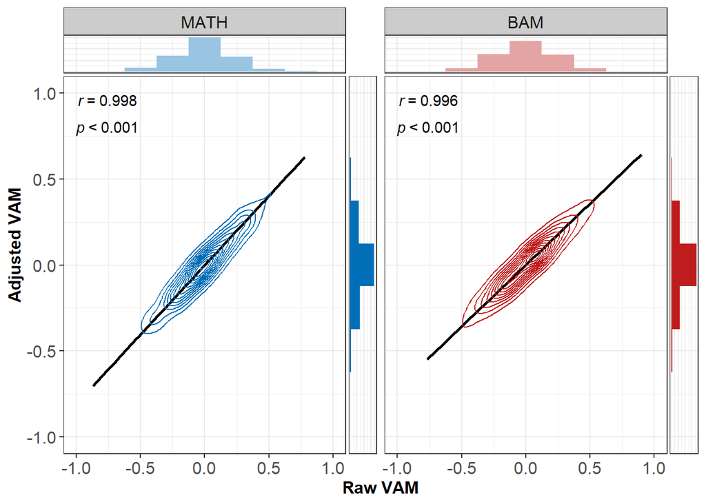

#### **Figure**

#### *Distribution of standardised adjusted VAMs*

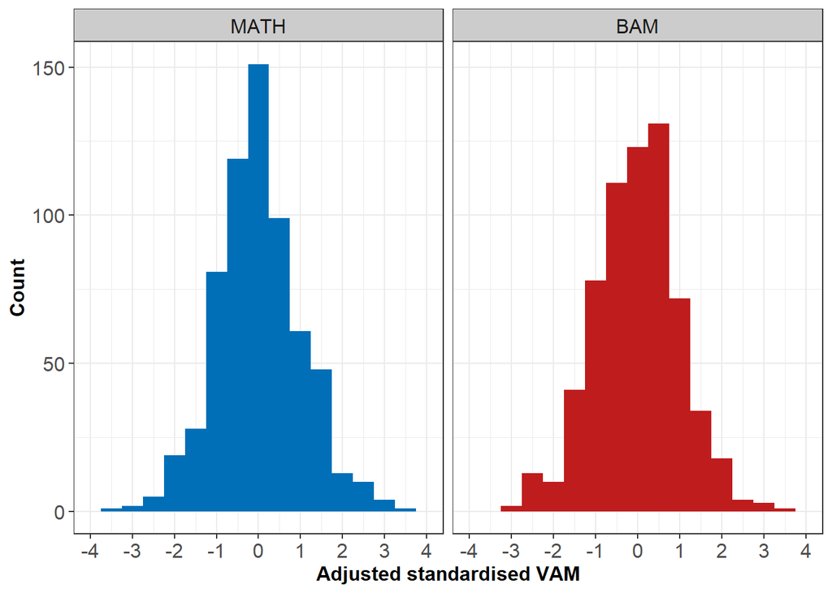

#### **Figure**

#### *Distribution of standardised VAMs before and after adjustment*

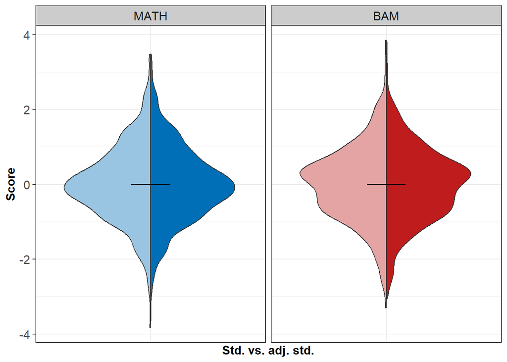

#### **Figure**

#### *Relationship between VAMs (adj. std.)*

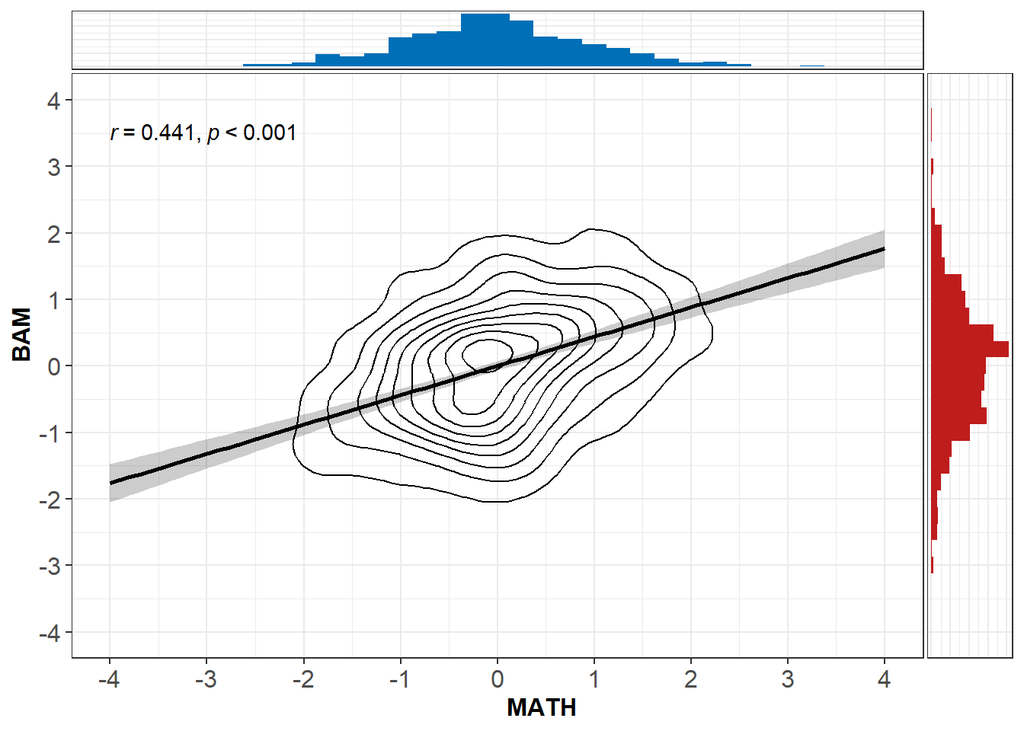

## NCA - FFT (adj.)

### State assessment in maths (std.)

OLS coefficients

| Domain | Coefficient | Item | Estimate | Std. Error | t value | p value |
| --- | --- | --- | --- | --- | --- | --- |
| FFT_CEV_adj | Intercept | CEV | -2.159 | 0.535 | -4.032 | 0.000 |
| FFT_CEV_adj | Beta | CEV | 0.809 | 0.200 | 4.043 | 0.000 |
| FFT_MSB_adj | Intercept | MSB | -1.668 | 0.489 | -3.408 | 0.001 |
| FFT_MSB_adj | Beta | MSB | 0.604 | 0.177 | 3.419 | 0.001 |
| FFT_MCP_adj | Intercept | MCP | -2.296 | 0.551 | -4.164 | 0.000 |
| FFT_MCP_adj | Beta | MCP | 0.853 | 0.204 | 4.174 | 0.000 |
| FFT_CERR_adj | Intercept | CERR | -1.307 | 0.435 | -3.002 | 0.003 |
| FFT_CERR_adj | Beta | CERR | 0.489 | 0.162 | 3.014 | 0.003 |
| FFT_ECL_adj | Intercept | ECL | -1.641 | 0.437 | -3.756 | 0.000 |
| FFT_ECL_adj | Beta | ECL | 0.646 | 0.171 | 3.772 | 0.000 |
| All | Intercept |  | -2.467 | 0.567 | -4.349 | 0.000 |
| All | Beta | MSB | 0.082 | 0.312 | 0.262 | 0.794 |
| All | Beta | MCP | 0.660 | 0.338 | 1.955 | 0.051 |
| All | Beta | CERR | -0.219 | 0.290 | -0.755 | 0.450 |
| All | Beta | ECL | 0.413 | 0.260 | 1.590 | 0.112 |

Note. Data from 642 classrooms is included.

NCA parameters

| Parameter | FFT_CEV_adj cr_fdh | FFT_MSB_adj cr_fdh | FFT_MCP_adj cr_fdh | FFT_CERR_adj cr_fdh | FFT_ECL_adj cr_fdh |
| --- | --- | --- | --- | --- | --- |
| Number of observations | 642 | 642 | 642 | 642 | 642 |
| Scope | 9.610385 | 10.31254 | 9.880449 | 11.16177 | 11.80047 |
| Ceiling zone | 2.054074 | 1.82917 | 2.093589 | 2.078063 | 1.932084 |
| Effect size | 0.2137348 | 0.1773734 | 0.2118921 | 0.1861769 | 0.1637294 |
| Slope | 5.129657 | 4.251478 | 4.409902 | 4.729525 | 6.523293 |
| Intercept | -10.10233 | -8.254585 | -8.601043 | -8.773697 | -12.10437 |
| p-value | 0.02759724 | 0.05239476 | 0.04849515 | 0.03909609 | 0.06869313 |
| p-accuracy | 0.003210732 | 0.004367227 | 0.0042102 | 0.003798873 | 0.004957368 |
| Complexity | 1 | 1 | 1 | 1 | 1 |
| Fit | 99.83494 | 93.73473 | 86.46646 | 98.57987 | 86.94198 |
| Ceiling accuracy | 99.06542 | 98.90966 | 99.06542 | 98.75389 | 99.22118 |
| Accuracy nof | 636 | 635 | 636 | 634 | 637 |
| Noise | 0.9 | 1.1 | 0.9 | 1.1 | 0.8 |
| Noise nof | 6 | 7 | 6 | 7 | 5 |
| Exceptions | 0 | 0 | 0 | 0.2 | 0 |
| Exceptions nof | 0 | 0 | 0 | 1 | 0 |
| Support | 5.1 | 5 | 7.3 | 5.6 | 4.5 |
| Support nof | 33 | 32 | 47 | 36 | 29 |
| Spread | 0.35 | 0.35 | 0.3 | 0.3 | 0.28 |
| Sharpness | 0.84 | 0.81 | 0.89 | 0.83 | 0.84 |
| Abs. ineff. | 5.502238 | 6.654199 | 5.69327 | 7.005642 | 7.936301 |
| Rel. ineff. | 57.25304 | 64.52532 | 57.62157 | 62.76463 | 67.25412 |
| Condition ineff. | 31.93599 | 34.25149 | 27.91431 | 38.6122 | 52.32675 |
| Outcome ineff. | 37.19594 | 46.0449 | 41.21104 | 39.34402 | 31.31183 |

Note. Data from 642 classrooms is included.  
This table was saved as coef_NCA_Y2_FFT_adj_VA_MATH_std.csv

#### **Figure**

#### *NCA Plot: FFT_CEV_adj - VA_MATH_std*

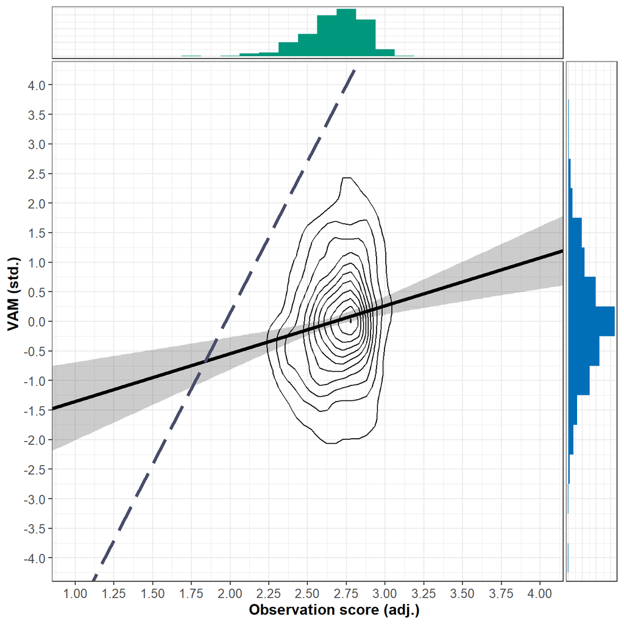

#### **Figure**

#### *NCA Plot: FFT indicators - VA_MATH_std*

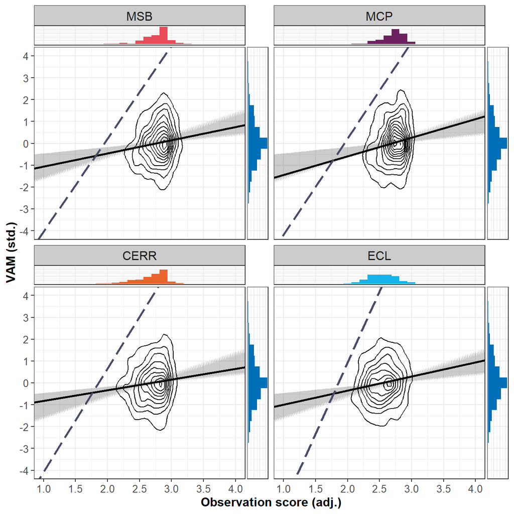

Bottlenecks (expressed as actual values)

| VA_MATH_std | cr_fdh FFT_CEV_adj | cr_fdh FFT_MSB_adj | cr_fdh FFT_MCP_adj | cr_fdh FFT_CERR_adj | cr_fdh FFT_ECL_adj |
| --- | --- | --- | --- | --- | --- |
| -3.5 | NN | NN | NN | NN | NN |
| -3.0 | NN | NN | NN | NN | NN |
| -2.5 | NN | NN | NN | NN | NN |
| -2.0 | NN | NN | NN | NN | NN |
| -1.5 | NN | NN | NN | NN | 1.626 |
| -1.0 | 1.774 | NN | NN | NN | 1.702 |
| -0.5 | 1.872 | NN | 1.837 | 1.749 | 1.779 |
| 0.0 | 1.969 | 1.942 | 1.950 | 1.855 | 1.856 |
| 0.5 | 2.067 | 2.059 | 2.064 | 1.961 | 1.932 |
| 1.0 | 2.164 | 2.177 | 2.177 | 2.067 | 2.009 |
| 1.5 | 2.262 | 2.294 | 2.291 | 2.172 | 2.086 |
| 2.0 | 2.359 | 2.412 | 2.404 | 2.278 | 2.162 |
| 2.5 | 2.457 | 2.530 | 2.517 | 2.384 | 2.239 |
| 3.0 | 2.554 | 2.647 | 2.631 | 2.489 | 2.315 |

Note. Data from 642 classrooms is included. NN = Not necessary.

Bottlenecks (expressed as percentage range)

| VA_MATH_std | cr_fdh FFT_CEV_adj | cr_fdh FFT_MSB_adj | cr_fdh FFT_MCP_adj | cr_fdh FFT_CERR_adj | cr_fdh FFT_ECL_adj |
| --- | --- | --- | --- | --- | --- |
| -3.5 | NN | NN | NN | NN | NN |
| -3.0 | NN | NN | NN | NN | NN |
| -2.5 | NN | NN | NN | NN | NN |
| -2.0 | NN | NN | NN | NN | NN |
| -1.5 | NN | NN | NN | NN | 0.5 |
| -1.0 | 1.8 | NN | NN | NN | 5.2 |
| -0.5 | 9.2 | NN | 5.4 | 6.4 | 10.0 |
| 0.0 | 16.6 | 7.9 | 13.8 | 13.3 | 14.7 |
| 0.5 | 24.0 | 16.2 | 22.2 | 20.2 | 19.4 |
| 1.0 | 31.4 | 24.5 | 30.6 | 27.2 | 24.2 |
| 1.5 | 38.8 | 32.9 | 39.0 | 34.1 | 28.9 |
| 2.0 | 46.2 | 41.2 | 47.4 | 41.0 | 33.7 |
| 2.5 | 53.6 | 49.5 | 55.8 | 47.9 | 38.4 |
| 3.0 | 61.1 | 57.9 | 64.2 | 54.8 | 43.2 |

Note. Data from 642 classrooms is included. NN = Not necessary.

Bottlenecks (expressed as percentiles)

| VA_MATH_std | cr_fdh FFT_CEV_adj | cr_fdh FFT_MSB_adj | cr_fdh FFT_MCP_adj | cr_fdh FFT_CERR_adj | cr_fdh FFT_ECL_adj |
| --- | --- | --- | --- | --- | --- |
| -3.5 | NN | NN | NN | NN | NN |
| -3.0 | NN | NN | NN | NN | NN |
| -2.5 | NN | NN | NN | NN | NN |
| -2.0 | NN | NN | NN | NN | NN |
| -1.5 | NN | NN | NN | NN | 0.2 |
| -1.0 | 0.3 | NN | NN | NN | 0.3 |
| -0.5 | 0.3 | NN | 0.2 | 0.5 | 0.3 |
| 0.0 | 0.5 | 0.5 | 0.3 | 0.6 | 0.3 |
| 0.5 | 0.8 | 1.6 | 0.3 | 0.9 | 0.6 |
| 1.0 | 2.0 | 2.3 | 1.2 | 2.0 | 1.2 |
| 1.5 | 3.7 | 3.0 | 1.9 | 4.0 | 3.9 |
| 2.0 | 7.2 | 6.5 | 8.9 | 8.6 | 4.7 |
| 2.5 | 13.4 | 14.0 | 19.2 | 10.6 | 11.8 |
| 3.0 | 24.3 | 26.2 | 32.1 | 19.8 | 14.0 |

Note. Data from 642 classrooms is included. NN = Not necessary.

### State assessment in maths (adj. std.)

OLS coefficients

| Domain | Coefficient | Item | Estimate | Std. Error | t value | p value |
| --- | --- | --- | --- | --- | --- | --- |
| FFT_CEV_adj | Intercept | CEV | -2.243 | 0.535 | -4.194 | 0.000 |
| FFT_CEV_adj | Beta | CEV | 0.841 | 0.200 | 4.205 | 0.000 |
| FFT_MSB_adj | Intercept | MSB | -1.734 | 0.489 | -3.546 | 0.000 |
| FFT_MSB_adj | Beta | MSB | 0.628 | 0.176 | 3.557 | 0.000 |
| FFT_MCP_adj | Intercept | MCP | -2.327 | 0.551 | -4.223 | 0.000 |
| FFT_MCP_adj | Beta | MCP | 0.864 | 0.204 | 4.233 | 0.000 |
| FFT_CERR_adj | Intercept | CERR | -1.381 | 0.435 | -3.176 | 0.002 |
| FFT_CERR_adj | Beta | CERR | 0.517 | 0.162 | 3.189 | 0.001 |
| FFT_ECL_adj | Intercept | ECL | -1.717 | 0.436 | -3.935 | 0.000 |
| FFT_ECL_adj | Beta | ECL | 0.676 | 0.171 | 3.951 | 0.000 |
| All | Intercept |  | -2.523 | 0.567 | -4.451 | 0.000 |
| All | Beta | MSB | 0.099 | 0.312 | 0.316 | 0.752 |
| All | Beta | MCP | 0.618 | 0.337 | 1.831 | 0.068 |
| All | Beta | CERR | -0.196 | 0.290 | -0.678 | 0.498 |
| All | Beta | ECL | 0.437 | 0.259 | 1.686 | 0.092 |

Note. Data from 642 classrooms is included.

NCA parameters

| Parameter | FFT_CEV_adj cr_fdh | FFT_MSB_adj cr_fdh | FFT_MCP_adj cr_fdh | FFT_CERR_adj cr_fdh | FFT_ECL_adj cr_fdh |
| --- | --- | --- | --- | --- | --- |
| Number of observations | 642 | 642 | 642 | 642 | 642 |
| Scope | 9.373285 | 10.05812 | 9.636686 | 10.88639 | 11.50934 |
| Ceiling zone | 2.149965 | 1.987814 | 2.0264 | 2.244681 | 2.255169 |
| Effect size | 0.2293715 | 0.1976329 | 0.2102797 | 0.2061914 | 0.1959426 |
| Slope | 4.537757 | 3.803869 | 4.185922 | 3.862256 | 4.525798 |
| Intercept | -8.879513 | -7.367344 | -8.014981 | -7.058711 | -8.356547 |
| p-value | 0.01629837 | 0.01809819 | 0.07259274 | 0.01269873 | 0.0069993 |
| p-accuracy | 0.002481715 | 0.002612761 | 0.005085456 | 0.002194588 | 0.001633993 |
| Complexity | 1 | 1 | 1 | 1 | 1 |
| Fit | 99.52476 | 95.42742 | 84.74703 | 99.34203 | 94.83346 |
| Ceiling accuracy | 98.90966 | 98.90966 | 99.22118 | 98.44237 | 98.59813 |
| Accuracy nof | 635 | 635 | 637 | 632 | 633 |
| Noise | 1.1 | 1.1 | 0.8 | 1.4 | 1.2 |
| Noise nof | 7 | 7 | 5 | 9 | 8 |
| Exceptions | 0 | 0 | 0 | 0.2 | 0.2 |
| Exceptions nof | 0 | 0 | 0 | 1 | 1 |
| Support | 7 | 6.5 | 6.7 | 7.2 | 11.5 |
| Support nof | 45 | 42 | 43 | 46 | 74 |
| Spread | 0.35 | 0.38 | 0.31 | 0.37 | 0.27 |
| Sharpness | 0.86 | 0.85 | 0.89 | 0.83 | 0.9 |
| Abs. ineff. | 5.073356 | 6.082488 | 5.583886 | 6.397031 | 6.998998 |
| Rel. ineff. | 54.1257 | 60.47343 | 57.94406 | 58.76171 | 60.81148 |
| Condition ineff. | 25.96302 | 27.53906 | 27.2078 | 29.39779 | 38.1646 |
| Outcome ineff. | 38.03866 | 45.45121 | 42.22465 | 41.59065 | 36.62446 |

Note. Data from 642 classrooms is included.  
This table was saved as coef_NCA_Y2_FFT_adj_VA_MATH_adj_std.csv

#### **Figure**

#### *NCA Plot: FFT_CEV_adj - VA_MATH_adj_std*

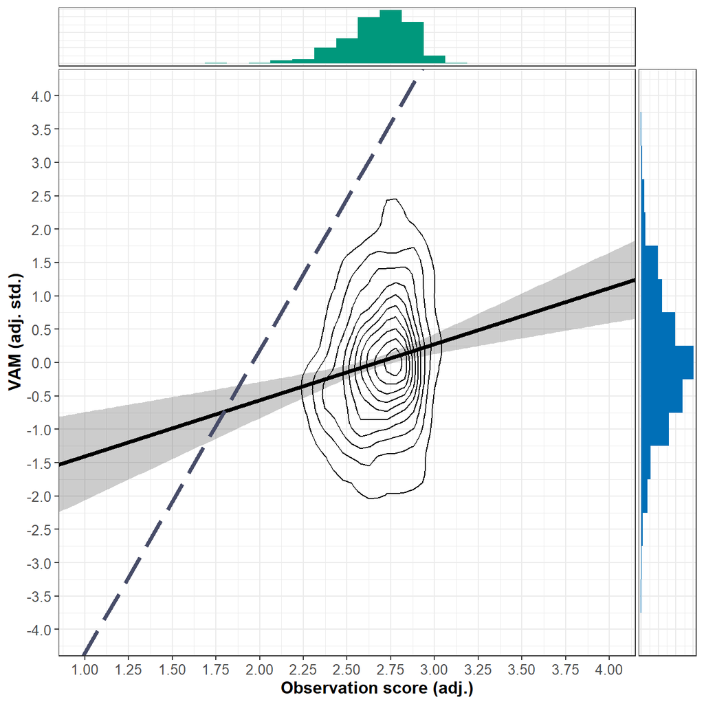

#### **Figure**

#### *NCA Plot: FFT indicators - VA_MATH_adj_std*

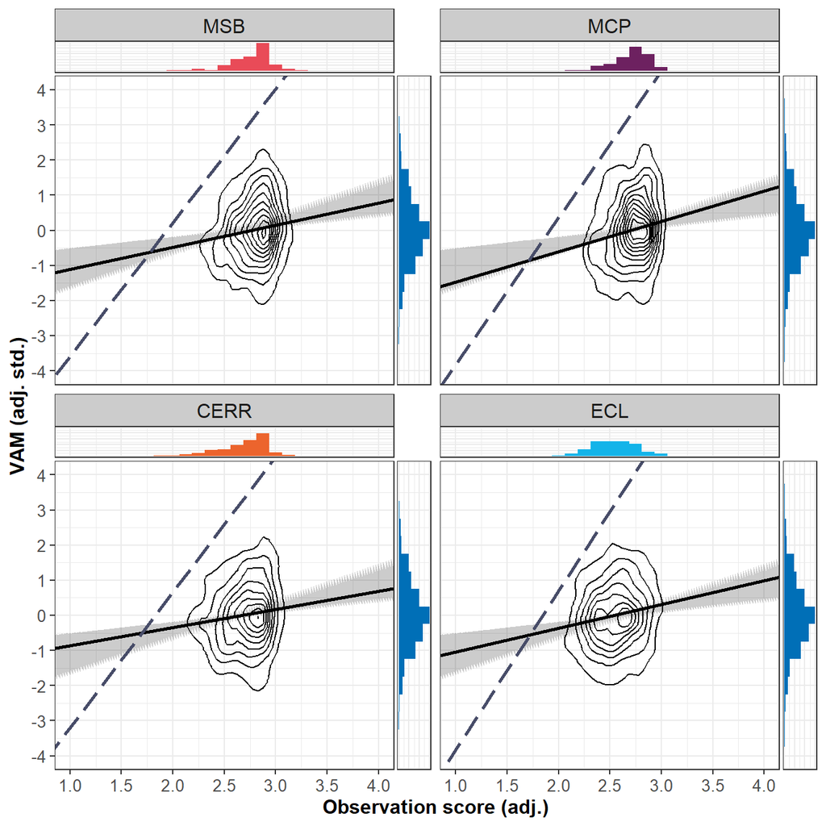

Bottlenecks (expressed as actual values)

| VA_MATH_adj_std | cr_fdh FFT_CEV_adj | cr_fdh FFT_MSB_adj | cr_fdh FFT_MCP_adj | cr_fdh FFT_CERR_adj | cr_fdh FFT_ECL_adj |
| --- | --- | --- | --- | --- | --- |
| -3.5 | NN | NN | NN | NN | NN |
| -3.0 | NN | NN | NN | NN | NN |
| -2.5 | NN | NN | NN | NN | NN |
| -2.0 | NN | NN | NN | NN | NN |
| -1.5 | NN | NN | NN | NN | NN |
| -1.0 | NN | NN | NN | NN | 1.625 |
| -0.5 | 1.847 | NN | 1.795 | 1.698 | 1.736 |
| 0.0 | 1.957 | 1.937 | 1.915 | 1.828 | 1.846 |
| 0.5 | 2.067 | 2.068 | 2.034 | 1.957 | 1.957 |
| 1.0 | 2.177 | 2.200 | 2.154 | 2.087 | 2.067 |
| 1.5 | 2.287 | 2.331 | 2.273 | 2.216 | 2.178 |
| 2.0 | 2.398 | 2.463 | 2.393 | 2.345 | 2.288 |
| 2.5 | 2.508 | 2.594 | 2.512 | 2.475 | 2.399 |
| 3.0 | 2.618 | 2.725 | 2.631 | 2.604 | 2.509 |

Note. Data from 642 classrooms is included. NN = Not necessary.

Bottlenecks (expressed as percentage range)

| VA_MATH_adj_std | cr_fdh FFT_CEV_adj | cr_fdh FFT_MSB_adj | cr_fdh FFT_MCP_adj | cr_fdh FFT_CERR_adj | cr_fdh FFT_ECL_adj |
| --- | --- | --- | --- | --- | --- |
| -3.5 | NN | NN | NN | NN | NN |
| -3.0 | NN | NN | NN | NN | NN |
| -2.5 | NN | NN | NN | NN | NN |
| -2.0 | NN | NN | NN | NN | NN |
| -1.5 | NN | NN | NN | NN | NN |
| -1.0 | NN | NN | NN | NN | 0.4 |
| -0.5 | 7.2 | NN | 2.4 | 3.0 | 7.3 |
| 0.0 | 15.6 | 7.5 | 11.2 | 11.5 | 14.1 |
| 0.5 | 24.0 | 16.8 | 20.0 | 20.0 | 21.0 |
| 1.0 | 32.4 | 26.2 | 28.9 | 28.5 | 27.8 |
| 1.5 | 40.8 | 35.5 | 37.7 | 36.9 | 34.7 |
| 2.0 | 49.1 | 44.8 | 46.5 | 45.4 | 41.5 |
| 2.5 | 57.5 | 54.1 | 55.4 | 53.9 | 48.4 |
| 3.0 | 65.9 | 63.4 | 64.2 | 62.4 | 55.2 |

Note. Data from 642 classrooms is included. NN = Not necessary.

Bottlenecks (expressed as percentiles)

| VA_MATH_adj_std | cr_fdh FFT_CEV_adj | cr_fdh FFT_MSB_adj | cr_fdh FFT_MCP_adj | cr_fdh FFT_CERR_adj | cr_fdh FFT_ECL_adj |
| --- | --- | --- | --- | --- | --- |
| -3.5 | NN | NN | NN | NN | NN |
| -3.0 | NN | NN | NN | NN | NN |
| -2.5 | NN | NN | NN | NN | NN |
| -2.0 | NN | NN | NN | NN | NN |
| -1.5 | NN | NN | NN | NN | NN |
| -1.0 | NN | NN | NN | NN | 0.2 |
| -0.5 | 0.3 | NN | 0.2 | 0.2 | 0.3 |
| 0.0 | 0.5 | 0.5 | 0.3 | 0.6 | 0.3 |
| 0.5 | 0.8 | 1.6 | 0.3 | 0.9 | 1.1 |
| 1.0 | 2.2 | 2.5 | 1.2 | 2.3 | 1.4 |
| 1.5 | 4.0 | 5.5 | 1.9 | 4.7 | 4.7 |
| 2.0 | 9.3 | 12.5 | 8.9 | 9.5 | 13.7 |
| 2.5 | 18.4 | 17.0 | 18.5 | 18.8 | 29.6 |
| 3.0 | 35.8 | 31.3 | 32.1 | 36.0 | 41.7 |

Note. Data from 642 classrooms is included. NN = Not necessary.

### Balanced assessment of maths (std.)

OLS coefficients

| Domain | Coefficient | Item | Estimate | Std. Error | t value | p value |
| --- | --- | --- | --- | --- | --- | --- |
| FFT_CEV_adj | Intercept | CEV | -1.593 | 0.538 | -2.959 | 0.003 |
| FFT_CEV_adj | Beta | CEV | 0.597 | 0.201 | 2.967 | 0.003 |
| FFT_MSB_adj | Intercept | MSB | -1.648 | 0.490 | -3.365 | 0.001 |
| FFT_MSB_adj | Beta | MSB | 0.596 | 0.177 | 3.376 | 0.001 |
| FFT_MCP_adj | Intercept | MCP | -0.771 | 0.558 | -1.382 | 0.167 |
| FFT_MCP_adj | Beta | MCP | 0.286 | 0.207 | 1.385 | 0.166 |
| FFT_CERR_adj | Intercept | CERR | -1.078 | 0.436 | -2.471 | 0.014 |
| FFT_CERR_adj | Beta | CERR | 0.403 | 0.163 | 2.481 | 0.013 |
| FFT_ECL_adj | Intercept | ECL | -1.338 | 0.439 | -3.051 | 0.002 |
| FFT_ECL_adj | Beta | ECL | 0.527 | 0.172 | 3.064 | 0.002 |
| All | Intercept |  | -1.299 | 0.568 | -2.288 | 0.022 |
| All | Beta | MSB | 0.879 | 0.313 | 2.810 | 0.005 |
| All | Beta | MCP | -0.750 | 0.338 | -2.218 | 0.027 |
| All | Beta | CERR | -0.127 | 0.290 | -0.437 | 0.662 |
| All | Beta | ECL | 0.484 | 0.260 | 1.861 | 0.063 |

Note. Data from 642 classrooms is included.

NCA parameters

| Parameter | FFT_CEV_adj cr_fdh | FFT_MSB_adj cr_fdh | FFT_MCP_adj cr_fdh | FFT_CERR_adj cr_fdh | FFT_ECL_adj cr_fdh |
| --- | --- | --- | --- | --- | --- |
| Number of observations | 642 | 642 | 642 | 642 | 642 |
| Scope | 9.430771 | 10.1198 | 9.695787 | 10.95316 | 11.57992 |
| Ceiling zone | 2.210978 | 1.473258 | 1.979265 | 2.493818 | 2.506797 |
| Effect size | 0.234443 | 0.1455817 | 0.2041366 | 0.2276803 | 0.2164778 |
| Slope | 5.082012 | 5.548247 | 6.943946 | 4.107581 | 3.875576 |
| Intercept | -9.781937 | -10.34121 | -13.62846 | -7.452142 | -6.820226 |
| p-value | 0.1327867 | 0.6913309 | 0.4134587 | 0.04849515 | 0.01949805 |
| p-accuracy | 0.006651022 | 0.009053941 | 0.009651914 | 0.0042102 | 0.002709991 |
| Complexity | 1 | 1 | 1 | 1 | 1 |
| Fit | 90.13753 | 75.24446 | 90.29144 | 91.38496 | 90.90839 |
| Ceiling accuracy | 99.22118 | 99.68847 | 99.53271 | 99.68847 | 99.37695 |
| Accuracy nof | 637 | 640 | 639 | 640 | 638 |
| Noise | 0.8 | 0.3 | 0.3 | 0.3 | 0.6 |
| Noise nof | 5 | 2 | 2 | 2 | 4 |
| Exceptions | 0 | 0 | 0.2 | 0 | 0 |
| Exceptions nof | 0 | 0 | 1 | 0 | 0 |
| Support | 6.5 | 1.4 | 2.8 | 9.7 | 12.6 |
| Support nof | 42 | 9 | 18 | 62 | 81 |
| Spread | 0.34 | 0.4 | 0.33 | 0.3 | 0.27 |
| Sharpness | 0.89 | 0.78 | 0.9 | 0.97 | 0.95 |
| Abs. ineff. | 5.008814 | 7.173286 | 5.737256 | 5.965522 | 6.566329 |
| Rel. ineff. | 53.11139 | 70.88366 | 59.17268 | 54.46394 | 56.70443 |
| Condition ineff. | 29.05397 | 48.34761 | 44.14441 | 27.83929 | 29.54908 |
| Outcome ineff. | 33.90947 | 43.63021 | 26.90557 | 36.89633 | 38.54506 |

Note. Data from 642 classrooms is included.  
This table was saved as coef_NCA_Y2_FFT_adj_VA_BAM_std.csv

#### **Figure**

#### *NCA Plot: FFT_CEV_adj - VA_BAM_std*

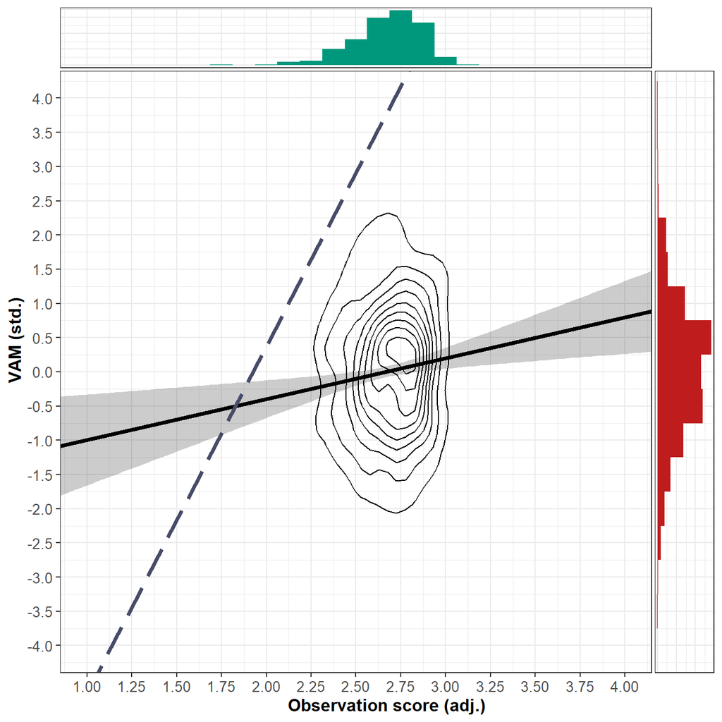

#### **Figure**

#### *NCA Plot: FFT indicators - VA_BAM_std*

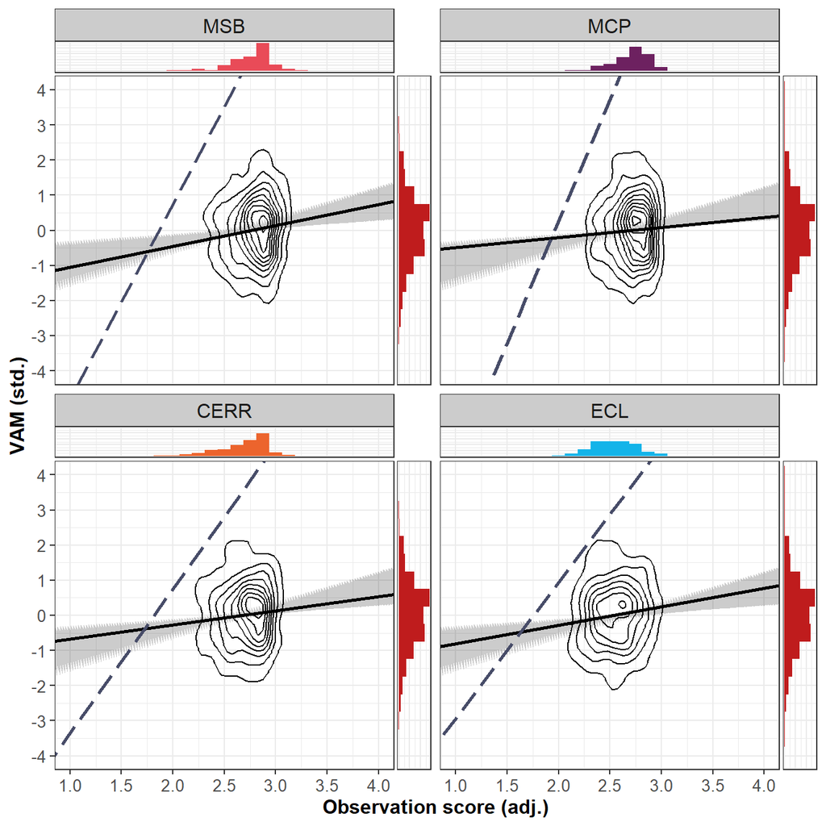

Bottlenecks (expressed as actual values)

| VA_BAM_std | cr_fdh FFT_CEV_adj | cr_fdh FFT_MSB_adj | cr_fdh FFT_MCP_adj | cr_fdh FFT_CERR_adj | cr_fdh FFT_ECL_adj |
| --- | --- | --- | --- | --- | --- |
| -3.0 | NN | NN | NN | NN | NN |
| -2.5 | NN | NN | NN | NN | NN |
| -2.0 | NN | NN | NN | NN | NN |
| -1.5 | NN | NN | NN | NN | NN |
| -1.0 | NN | NN | 1.819 | NN | NN |
| -0.5 | 1.826 | NN | 1.891 | 1.693 | 1.631 |
| 0.0 | 1.925 | 1.864 | 1.963 | 1.814 | 1.760 |
| 0.5 | 2.023 | 1.954 | 2.035 | 1.936 | 1.889 |
| 1.0 | 2.122 | 2.044 | 2.107 | 2.058 | 2.018 |
| 1.5 | 2.220 | 2.134 | 2.179 | 2.179 | 2.147 |
| 2.0 | 2.318 | 2.224 | 2.251 | 2.301 | 2.276 |
| 2.5 | 2.417 | 2.314 | 2.323 | 2.423 | 2.405 |
| 3.0 | 2.515 | 2.405 | 2.395 | 2.545 | 2.534 |
| 3.5 | 2.614 | 2.495 | 2.467 | 2.666 | 2.663 |

Note. Data from 642 classrooms is included. NN = Not necessary.

Bottlenecks (expressed as percentage range)

| VA_BAM_std | cr_fdh FFT_CEV_adj | cr_fdh FFT_MSB_adj | cr_fdh FFT_MCP_adj | cr_fdh FFT_CERR_adj | cr_fdh FFT_ECL_adj |
| --- | --- | --- | --- | --- | --- |
| -3.0 | NN | NN | NN | NN | NN |
| -2.5 | NN | NN | NN | NN | NN |
| -2.0 | NN | NN | NN | NN | NN |
| -1.5 | NN | NN | NN | NN | NN |
| -1.0 | NN | NN | 4.1 | NN | NN |
| -0.5 | 5.7 | NN | 9.4 | 2.7 | 0.8 |
| 0.0 | 13.2 | 2.3 | 14.7 | 10.6 | 8.8 |
| 0.5 | 20.7 | 8.7 | 20.1 | 18.6 | 16.8 |
| 1.0 | 28.2 | 15.1 | 25.4 | 26.6 | 24.8 |
| 1.5 | 35.6 | 21.5 | 30.7 | 34.5 | 32.7 |
| 2.0 | 43.1 | 27.9 | 36.0 | 42.5 | 40.7 |
| 2.5 | 50.6 | 34.3 | 41.4 | 50.5 | 48.7 |
| 3.0 | 58.1 | 40.7 | 46.7 | 58.5 | 56.7 |
| 3.5 | 65.6 | 47.1 | 52.0 | 66.4 | 64.7 |

Note. Data from 642 classrooms is included. NN = Not necessary.

Bottlenecks (expressed as percentiles)

| VA_BAM_std | cr_fdh FFT_CEV_adj | cr_fdh FFT_MSB_adj | cr_fdh FFT_MCP_adj | cr_fdh FFT_CERR_adj | cr_fdh FFT_ECL_adj |
| --- | --- | --- | --- | --- | --- |
| -3.0 | NN | NN | NN | NN | NN |
| -2.5 | NN | NN | NN | NN | NN |
| -2.0 | NN | NN | NN | NN | NN |
| -1.5 | NN | NN | NN | NN | NN |
| -1.0 | NN | NN | 0.2 | NN | NN |
| -0.5 | 0.3 | NN | 0.2 | 0.2 | 0.2 |
| 0.0 | 0.5 | 0.2 | 0.3 | 0.5 | 0.3 |
| 0.5 | 0.6 | 0.5 | 0.3 | 0.9 | 0.5 |
| 1.0 | 1.1 | 1.2 | 1.2 | 2.0 | 1.2 |
| 1.5 | 2.6 | 1.6 | 1.2 | 4.2 | 4.5 |
| 2.0 | 4.8 | 2.5 | 1.9 | 8.6 | 12.8 |
| 2.5 | 9.8 | 5.1 | 2.8 | 17.3 | 29.6 |
| 3.0 | 19.0 | 6.2 | 8.9 | 22.0 | 51.9 |
| 3.5 | 35.2 | 12.9 | 16.2 | 40.2 | 72.9 |

Note. Data from 642 classrooms is included. NN = Not necessary.

### Balanced assessment of maths (adj. std.)

OLS coefficients

| Domain | Coefficient | Item | Estimate | Std. Error | t value | p value |
| --- | --- | --- | --- | --- | --- | --- |
| FFT_CEV_adj | Intercept | CEV | -1.652 | 0.538 | -3.069 | 0.002 |
| FFT_CEV_adj | Beta | CEV | 0.619 | 0.201 | 3.077 | 0.002 |
| FFT_MSB_adj | Intercept | MSB | -1.689 | 0.489 | -3.451 | 0.001 |
| FFT_MSB_adj | Beta | MSB | 0.611 | 0.177 | 3.462 | 0.001 |
| FFT_MCP_adj | Intercept | MCP | -0.815 | 0.558 | -1.461 | 0.145 |
| FFT_MCP_adj | Beta | MCP | 0.303 | 0.207 | 1.464 | 0.144 |
| FFT_CERR_adj | Intercept | CERR | -1.117 | 0.436 | -2.562 | 0.011 |
| FFT_CERR_adj | Beta | CERR | 0.418 | 0.163 | 2.572 | 0.010 |
| FFT_ECL_adj | Intercept | ECL | -1.394 | 0.438 | -3.181 | 0.002 |
| FFT_ECL_adj | Beta | ECL | 0.549 | 0.172 | 3.194 | 0.001 |
| All | Intercept |  | -1.355 | 0.567 | -2.388 | 0.017 |
| All | Beta | MSB | 0.882 | 0.313 | 2.822 | 0.005 |
| All | Beta | MCP | -0.752 | 0.338 | -2.226 | 0.026 |
| All | Beta | CERR | -0.129 | 0.290 | -0.445 | 0.657 |
| All | Beta | ECL | 0.506 | 0.260 | 1.950 | 0.052 |

Note. Data from 642 classrooms is included.

NCA parameters

| Parameter | FFT_CEV_adj cr_fdh | FFT_MSB_adj cr_fdh | FFT_MCP_adj cr_fdh | FFT_CERR_adj cr_fdh | FFT_ECL_adj cr_fdh |
| --- | --- | --- | --- | --- | --- |
| Number of observations | 642 | 642 | 642 | 642 | 642 |
| Scope | 9.017093 | 9.675901 | 9.270485 | 10.4727 | 11.07197 |
| Ceiling zone | 2.249803 | 1.487933 | 1.959039 | 2.497111 | 2.42773 |
| Effect size | 0.2495043 | 0.1537772 | 0.21132 | 0.23844 | 0.2192681 |
| Slope | 4.771925 | 5.461987 | 6.330331 | 3.756358 | 3.941058 |
| Intercept | -9.183843 | -10.22341 | -12.33551 | -6.728731 | -6.944356 |
| p-value | 0.0809919 | 0.6286371 | 0.3760624 | 0.03329667 | 0.02059794 |
| p-accuracy | 0.005347226 | 0.009469943 | 0.009493987 | 0.003516374 | 0.002783816 |
| Complexity | 1 | 1 | 1 | 1 | 1 |
| Fit | 90.84278 | 73.63565 | 92.75491 | 94.67045 | 87.26537 |
| Ceiling accuracy | 99.22118 | 99.68847 | 99.53271 | 99.68847 | 99.22118 |
| Accuracy nof | 637 | 640 | 639 | 640 | 637 |
| Noise | 0.8 | 0.3 | 0.3 | 0.3 | 0.8 |
| Noise nof | 5 | 2 | 2 | 2 | 5 |
| Exceptions | 0 | 0 | 0.2 | 0 | 0 |
| Exceptions nof | 0 | 0 | 1 | 0 | 0 |
| Support | 7.8 | 1.4 | 3 | 9.3 | 11.7 |
| Support nof | 50 | 9 | 19 | 60 | 75 |
| Spread | 0.32 | 0.4 | 0.32 | 0.3 | 0.28 |
| Sharpness | 0.91 | 0.78 | 0.9 | 0.97 | 0.94 |
| Abs. ineff. | 4.517487 | 6.700036 | 5.352407 | 5.478479 | 6.216513 |
| Rel. ineff. | 50.09915 | 69.24457 | 57.736 | 52.31199 | 56.14639 |
| Condition ineff. | 26.14513 | 47.68272 | 41.79958 | 24.4913 | 31.24741 |
| Outcome ineff. | 32.4339 | 41.21362 | 27.38197 | 36.84436 | 36.21533 |

Note. Data from 642 classrooms is included.  
This table was saved as coef_NCA_Y2_FFT_adj_VA_BAM_adj_std.csv

#### **Figure**

#### *NCA Plot: FFT_CEV_adj - VA_BAM_adj_std*

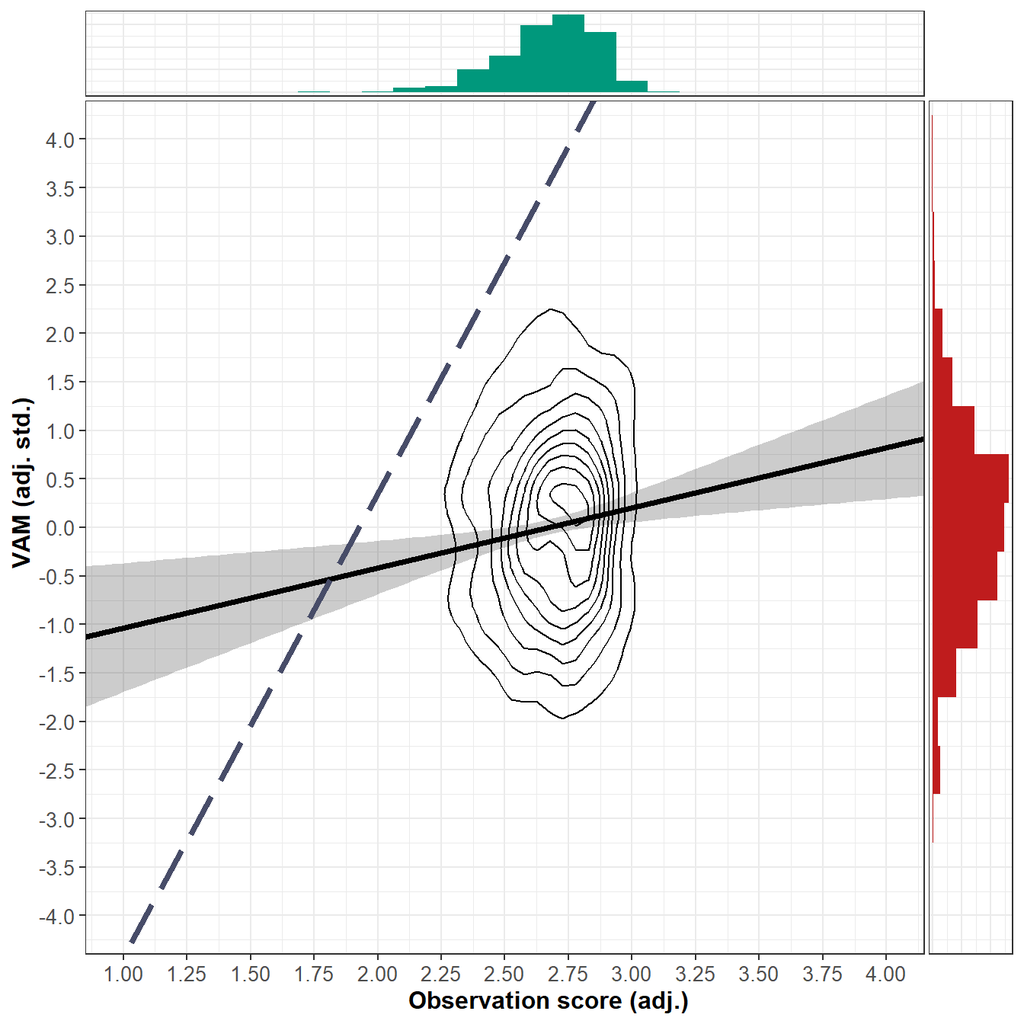

#### **Figure**

#### *NCA Plot: FFT indicators - VA_BAM_adj_std*

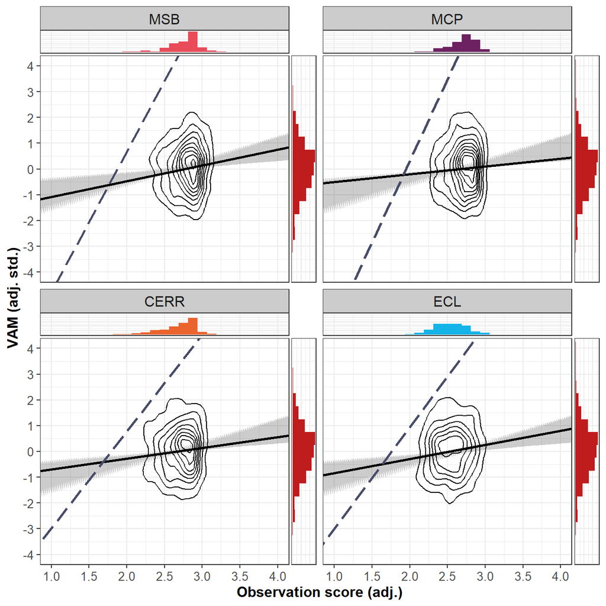

Bottlenecks (expressed as actual values)

| VA_BAM_adj_std | cr_fdh FFT_CEV_adj | cr_fdh FFT_MSB_adj | cr_fdh FFT_MCP_adj | cr_fdh FFT_CERR_adj | cr_fdh FFT_ECL_adj |
| --- | --- | --- | --- | --- | --- |
| -3.0 | NN | NN | NN | NN | NN |
| -2.5 | NN | NN | NN | NN | NN |
| -2.0 | NN | NN | NN | NN | NN |
| -1.5 | NN | NN | NN | NN | NN |
| -1.0 | NN | NN | 1.791 | NN | NN |
| -0.5 | 1.820 | NN | 1.870 | 1.658 | 1.635 |
| 0.0 | 1.925 | 1.872 | 1.949 | 1.791 | 1.762 |
| 0.5 | 2.029 | 1.963 | 2.028 | 1.924 | 1.889 |
| 1.0 | 2.134 | 2.055 | 2.107 | 2.058 | 2.016 |
| 1.5 | 2.239 | 2.146 | 2.186 | 2.191 | 2.143 |
| 2.0 | 2.344 | 2.238 | 2.265 | 2.324 | 2.270 |
| 2.5 | 2.448 | 2.329 | 2.344 | 2.457 | 2.396 |
| 3.0 | 2.553 | 2.421 | 2.423 | 2.590 | 2.523 |
| 3.5 | 2.658 | 2.513 | 2.502 | 2.723 | 2.650 |

Note. Data from 642 classrooms is included. NN = Not necessary.

Bottlenecks (expressed as percentage range)

| VA_BAM_adj_std | cr_fdh FFT_CEV_adj | cr_fdh FFT_MSB_adj | cr_fdh FFT_MCP_adj | cr_fdh FFT_CERR_adj | cr_fdh FFT_ECL_adj |
| --- | --- | --- | --- | --- | --- |
| -3.0 | NN | NN | NN | NN | NN |
| -2.5 | NN | NN | NN | NN | NN |
| -2.0 | NN | NN | NN | NN | NN |
| -1.5 | NN | NN | NN | NN | NN |
| -1.0 | NN | NN | 2.0 | NN | NN |
| -0.5 | 5.2 | NN | 7.9 | 0.4 | 1.1 |
| 0.0 | 13.2 | 2.9 | 13.7 | 9.1 | 8.9 |
| 0.5 | 21.1 | 9.4 | 19.5 | 17.8 | 16.8 |
| 1.0 | 29.1 | 15.9 | 25.4 | 26.6 | 24.6 |
| 1.5 | 37.1 | 22.4 | 31.2 | 35.3 | 32.5 |
| 2.0 | 45.0 | 28.9 | 37.1 | 44.0 | 40.3 |
| 2.5 | 53.0 | 35.3 | 42.9 | 52.7 | 48.2 |
| 3.0 | 61.0 | 41.8 | 48.8 | 61.4 | 56.1 |
| 3.5 | 69.0 | 48.3 | 54.6 | 70.1 | 63.9 |

Note. Data from 642 classrooms is included. NN = Not necessary.

Bottlenecks (expressed as percentiles)

| VA_BAM_adj_std | cr_fdh FFT_CEV_adj | cr_fdh FFT_MSB_adj | cr_fdh FFT_MCP_adj | cr_fdh FFT_CERR_adj | cr_fdh FFT_ECL_adj |
| --- | --- | --- | --- | --- | --- |
| -3.0 | NN | NN | NN | NN | NN |
| -2.5 | NN | NN | NN | NN | NN |
| -2.0 | NN | NN | NN | NN | NN |
| -1.5 | NN | NN | NN | NN | NN |
| -1.0 | NN | NN | 0.2 | NN | NN |
| -0.5 | 0.3 | NN | 0.2 | 0.2 | 0.2 |
| 0.0 | 0.5 | 0.2 | 0.3 | 0.5 | 0.3 |
| 0.5 | 0.6 | 0.5 | 0.3 | 0.8 | 0.5 |
| 1.0 | 1.1 | 1.6 | 1.2 | 2.0 | 1.2 |
| 1.5 | 2.6 | 1.6 | 1.2 | 4.5 | 4.4 |
| 2.0 | 5.8 | 2.5 | 1.9 | 9.2 | 12.3 |
| 2.5 | 13.2 | 5.5 | 7.8 | 18.8 | 29.6 |
| 3.0 | 24.1 | 6.5 | 9.8 | 35.0 | 51.9 |
| 3.5 | 42.5 | 13.9 | 18.5 | 53.9 | 63.1 |

Note. Data from 642 classrooms is included. NN = Not necessary.

## Combined tables

OLS coefficients

| Observation score | Model 1 B | Model 1 SE | Model 1 β | Model 1 t | Model 1 p | Model 2 B | Model 2 SE | Model 2 β | Model 2 t | Model 2 p |
| --- | --- | --- | --- | --- | --- | --- | --- | --- | --- | --- |
| VA_MATH_adj_std |  |  |  |  |  |  |  |  |  |  |
| CEV | 0.84 | 0.20 | 0.16 | 4.205 | <0.001 |  |  |  |  |  |
| MSB | 0.63 | 0.18 | 0.14 | 3.557 | <0.001 | 0.10 | 0.31 | 0.02 | 0.316 | 0.752 |
| MCP | 0.86 | 0.20 | 0.17 | 4.233 | <0.001 | 0.62 | 0.34 | 0.12 | 1.831 | 0.068 |
| CERR | 0.52 | 0.16 | 0.13 | 3.189 | 0.001 | -0.20 | 0.29 | -0.05 | -0.678 | 0.498 |
| ECL | 0.68 | 0.17 | 0.15 | 3.951 | <0.001 | 0.44 | 0.26 | 0.10 | 1.686 | 0.092 |
| VA_BAM_adj_std |  |  |  |  |  |  |  |  |  |  |
| CEV | 0.62 | 0.20 | 0.12 | 3.077 | 0.002 |  |  |  |  |  |
| MSB | 0.61 | 0.18 | 0.14 | 3.462 | 0.001 | 0.88 | 0.31 | 0.20 | 2.822 | 0.005 |
| MCP | 0.30 | 0.21 | 0.06 | 1.464 | 0.144 | -0.75 | 0.34 | -0.14 | -2.226 | 0.026 |
| CERR | 0.42 | 0.16 | 0.10 | 2.572 | 0.010 | -0.13 | 0.29 | -0.03 | -0.445 | 0.657 |
| ECL | 0.55 | 0.17 | 0.13 | 3.194 | 0.001 | 0.51 | 0.26 | 0.12 | 1.950 | 0.052 |

Note. Data from 642 classrooms is included. In model 1, each predictor was entered seperately. In model 2, all predictors were entered together.  
This table was saved as coef_ols.csv

NCA bottlenecks

| VAM (adj. std.) | MATH Adj. | MATH Adj. std. | MATH % range | MATH Percentile | BAM Adj. | BAM Adj. std. | BAM % range | BAM Percentile |
| --- | --- | --- | --- | --- | --- | --- | --- | --- |
| -3.5 | NN | NN | NN | NN |  |  |  |  |
| -3.0 | NN | NN | NN | NN | NN | NN | NN | NN |
| -2.5 | NN | NN | NN | NN | NN | NN | NN | NN |
| -2.0 | NN | NN | NN | NN | NN | NN | NN | NN |
| -1.5 | NN | NN | NN | NN | NN | NN | NN | NN |
| -1.0 | NN | NN | NN | NN | NN | NN | NN | NN |
| -0.5 | 1.847 | -4.208 | 7.2 | 0.3 | 1.820 | -4.346 | 5.2 | 0.3 |
| 0.0 | 1.957 | -3.643 | 15.6 | 0.5 | 1.925 | -3.809 | 13.2 | 0.5 |
| 0.5 | 2.067 | -3.078 | 24.0 | 0.8 | 2.029 | -3.271 | 21.1 | 0.6 |
| 1.0 | 2.177 | -2.513 | 32.4 | 2.2 | 2.134 | -2.734 | 29.1 | 1.1 |
| 1.5 | 2.287 | -1.948 | 40.8 | 4.0 | 2.239 | -2.196 | 37.1 | 2.6 |
| 2.0 | 2.398 | -1.383 | 49.1 | 9.3 | 2.344 | -1.659 | 45.0 | 5.8 |
| 2.5 | 2.508 | -0.818 | 57.5 | 18.4 | 2.448 | -1.122 | 53.0 | 13.2 |
| 3.0 | 2.618 | -0.252 | 65.9 | 35.8 | 2.553 | -0.584 | 61.0 | 24.1 |
| 3.5 |  |  |  |  | 2.658 | -0.047 | 69.0 | 42.5 |

Note. Data from 642 classrooms is included. Bottlenecks are shown for CEV where the values are shown as adjusted values, adjusted standardised values, percentage range or percentiles. NCA ceiling line = CR-FDH. NN = not necessary.  
This table was saved as coef_bottlenecks.csv

#### **Figure**

#### *NCA Plot: VAMs - FFT_CEV_adj*

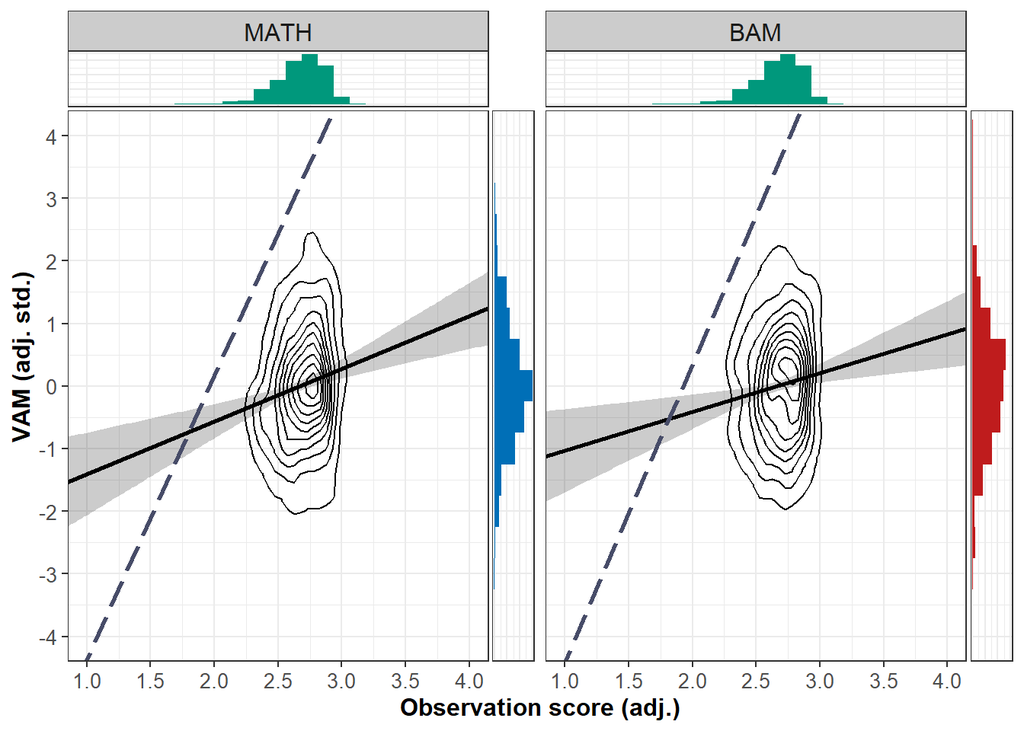

## NCA - FFT (adj. std.)

### State assessment in maths (std.)

OLS coefficients

| Domain | Coefficient | Item | Estimate | Std. Error | t value | p value |
| --- | --- | --- | --- | --- | --- | --- |
| FFT_CEV_adj_std | Intercept | CEV | 0.000 | 0.039 | 0.000 | 1.000 |
| FFT_CEV_adj_std | Beta | CEV | 0.158 | 0.039 | 4.043 | 0.000 |
| FFT_MSB_adj_std | Intercept | MSB | 0.000 | 0.039 | 0.000 | 1.000 |
| FFT_MSB_adj_std | Beta | MSB | 0.134 | 0.039 | 3.419 | 0.001 |
| FFT_MCP_adj_std | Intercept | MCP | 0.000 | 0.039 | 0.000 | 1.000 |
| FFT_MCP_adj_std | Beta | MCP | 0.163 | 0.039 | 4.174 | 0.000 |
| FFT_CERR_adj_std | Intercept | CERR | 0.000 | 0.039 | 0.000 | 1.000 |
| FFT_CERR_adj_std | Beta | CERR | 0.118 | 0.039 | 3.014 | 0.003 |
| FFT_ECL_adj_std | Intercept | ECL | 0.000 | 0.039 | 0.000 | 1.000 |
| FFT_ECL_adj_std | Beta | ECL | 0.147 | 0.039 | 3.772 | 0.000 |
| All | Intercept |  | 0.000 | 0.039 | 0.000 | 1.000 |
| All | Beta | MSB | 0.018 | 0.069 | 0.262 | 0.794 |
| All | Beta | MCP | 0.126 | 0.064 | 1.955 | 0.051 |
| All | Beta | CERR | -0.053 | 0.070 | -0.755 | 0.450 |
| All | Beta | ECL | 0.094 | 0.059 | 1.590 | 0.112 |

Note. Data from 642 classrooms is included.

NCA parameters

| Parameter | FFT_CEV_adj_std cr_fdh | FFT_MSB_adj_std cr_fdh | FFT_MCP_adj_std cr_fdh | FFT_CERR_adj_std cr_fdh | FFT_ECL_adj_std cr_fdh |
| --- | --- | --- | --- | --- | --- |
| Number of observations | 642 | 642 | 642 | 642 | 642 |
| Scope | 49.29007 | 46.49686 | 51.74163 | 46.12976 | 51.6825 |
| Ceiling zone | 10.535 | 8.247306 | 10.96364 | 8.588294 | 8.461946 |
| Effect size | 0.2137348 | 0.1773734 | 0.2118921 | 0.1861769 | 0.1637294 |
| Slope | 1.000161 | 0.9429354 | 0.8421036 | 1.144378 | 1.489439 |
| Intercept | 3.579263 | 3.48985 | 3.273343 | 3.865098 | 4.472674 |
| p-value | 0.02819718 | 0.05839416 | 0.0459954 | 0.03729627 | 0.07529247 |
| p-accuracy | 0.003244442 | 0.004595866 | 0.004105637 | 0.003713874 | 0.005171614 |
| Complexity | 1 | 1 | 1 | 1 | 1 |
| Fit | 99.83494 | 93.73473 | 86.46646 | 98.57987 | 86.94198 |
| Ceiling accuracy | 99.06542 | 98.90966 | 99.06542 | 98.75389 | 99.22118 |
| Accuracy nof | 636 | 635 | 636 | 634 | 637 |
| Noise | 0.9 | 1.1 | 0.9 | 1.1 | 0.8 |
| Noise nof | 6 | 7 | 6 | 7 | 5 |
| Exceptions | 0 | 0 | 0 | 0.2 | 0 |
| Exceptions nof | 0 | 0 | 0 | 1 | 0 |
| Support | 5.1 | 5 | 7.3 | 5.6 | 4.5 |
| Support nof | 33 | 32 | 47 | 36 | 29 |
| Spread | 0.35 | 0.35 | 0.3 | 0.3 | 0.28 |
| Sharpness | 0.84 | 0.81 | 0.89 | 0.83 | 0.84 |
| Abs. ineff. | 28.22006 | 30.00225 | 29.81434 | 28.95317 | 34.75861 |
| Rel. ineff. | 57.25304 | 64.52532 | 57.62157 | 62.76463 | 67.25412 |
| Condition ineff. | 31.93599 | 34.25149 | 27.91431 | 38.6122 | 52.32675 |
| Outcome ineff. | 37.19594 | 46.0449 | 41.21104 | 39.34402 | 31.31183 |

Note. Data from 642 classrooms is included.  
This table was saved as coef_NCA_Y2_FFT_adj_std_VA_MATH_std.csv

#### **Figure**

#### *NCA Plot: FFT_CEV_adj_std - VA_MATH_std*

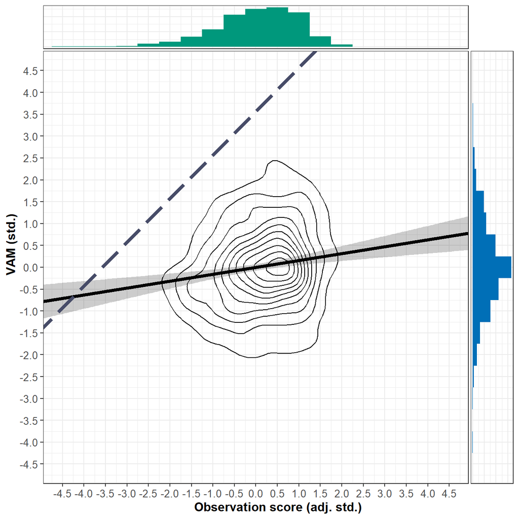

#### **Figure**

#### *NCA Plot: FFT indicators - VA_MATH_std*

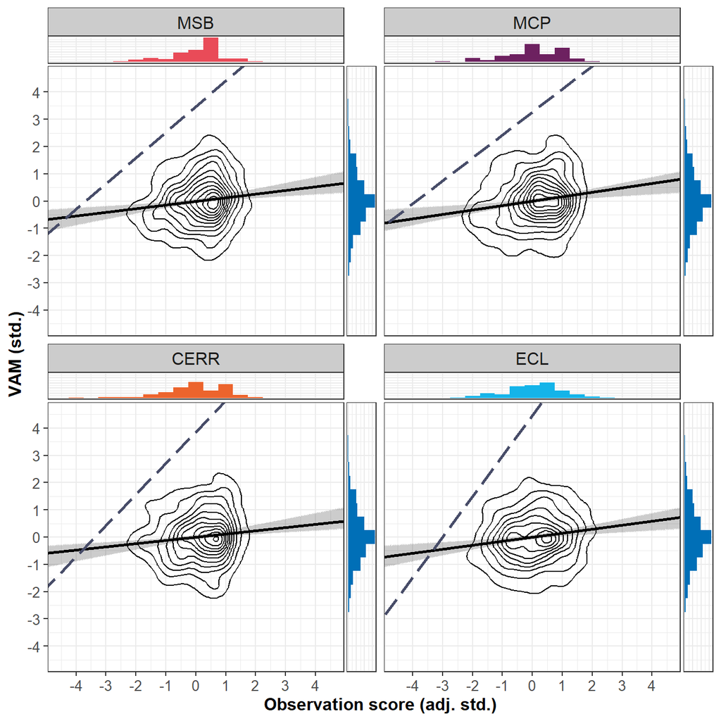

Bottlenecks (expressed as actual values)

| VA_MATH_std | cr_fdh FFT_CEV_adj_std | cr_fdh FFT_MSB_adj_std | cr_fdh FFT_MCP_adj_std | cr_fdh FFT_CERR_adj_std | cr_fdh FFT_ECL_adj_std |
| --- | --- | --- | --- | --- | --- |
| -3.5 | NN | NN | NN | NN | NN |
| -3.0 | NN | NN | NN | NN | NN |
| -2.5 | NN | NN | NN | NN | NN |
| -2.0 | NN | NN | NN | NN | NN |
| -1.5 | NN | NN | NN | NN | -4.010 |
| -1.0 | -4.579 | NN | NN | NN | -3.674 |
| -0.5 | -4.079 | NN | -4.481 | -3.814 | -3.339 |
| 0.0 | -3.579 | -3.701 | -3.887 | -3.377 | -3.003 |
| 0.5 | -3.079 | -3.171 | -3.293 | -2.941 | -2.667 |
| 1.0 | -2.579 | -2.641 | -2.700 | -2.504 | -2.332 |
| 1.5 | -2.079 | -2.110 | -2.106 | -2.067 | -1.996 |
| 2.0 | -1.579 | -1.580 | -1.512 | -1.630 | -1.660 |
| 2.5 | -1.079 | -1.050 | -0.918 | -1.193 | -1.324 |
| 3.0 | -0.579 | -0.519 | -0.325 | -0.756 | -0.989 |

Note. Data from 642 classrooms is included. NN = Not necessary.

Bottlenecks (expressed as percentage range)

| VA_MATH_std | cr_fdh FFT_CEV_adj_std | cr_fdh FFT_MSB_adj_std | cr_fdh FFT_MCP_adj_std | cr_fdh FFT_CERR_adj_std | cr_fdh FFT_ECL_adj_std |
| --- | --- | --- | --- | --- | --- |
| -3.5 | NN | NN | NN | NN | NN |
| -3.0 | NN | NN | NN | NN | NN |
| -2.5 | NN | NN | NN | NN | NN |
| -2.0 | NN | NN | NN | NN | NN |
| -1.5 | NN | NN | NN | NN | 0.5 |
| -1.0 | 1.8 | NN | NN | NN | 5.2 |
| -0.5 | 9.2 | NN | 5.4 | 6.4 | 10.0 |
| 0.0 | 16.6 | 7.9 | 13.8 | 13.3 | 14.7 |
| 0.5 | 24.0 | 16.2 | 22.2 | 20.2 | 19.4 |
| 1.0 | 31.4 | 24.5 | 30.6 | 27.2 | 24.2 |
| 1.5 | 38.8 | 32.9 | 39.0 | 34.1 | 28.9 |
| 2.0 | 46.2 | 41.2 | 47.4 | 41.0 | 33.7 |
| 2.5 | 53.6 | 49.5 | 55.8 | 47.9 | 38.4 |
| 3.0 | 61.1 | 57.9 | 64.2 | 54.8 | 43.2 |

Note. Data from 642 classrooms is included. NN = Not necessary.

Bottlenecks (expressed as percentiles)

| VA_MATH_std | cr_fdh FFT_CEV_adj_std | cr_fdh FFT_MSB_adj_std | cr_fdh FFT_MCP_adj_std | cr_fdh FFT_CERR_adj_std | cr_fdh FFT_ECL_adj_std |
| --- | --- | --- | --- | --- | --- |
| -3.5 | NN | NN | NN | NN | NN |
| -3.0 | NN | NN | NN | NN | NN |
| -2.5 | NN | NN | NN | NN | NN |
| -2.0 | NN | NN | NN | NN | NN |
| -1.5 | NN | NN | NN | NN | 0.2 |
| -1.0 | 0.3 | NN | NN | NN | 0.3 |
| -0.5 | 0.3 | NN | 0.2 | 0.5 | 0.3 |
| 0.0 | 0.5 | 0.5 | 0.3 | 0.6 | 0.3 |
| 0.5 | 0.8 | 1.6 | 0.3 | 0.9 | 0.6 |
| 1.0 | 2.0 | 2.3 | 1.2 | 2.0 | 1.2 |
| 1.5 | 3.7 | 3.0 | 1.9 | 4.0 | 3.9 |
| 2.0 | 7.2 | 6.5 | 8.9 | 8.6 | 4.7 |
| 2.5 | 13.4 | 14.0 | 19.2 | 10.6 | 11.8 |
| 3.0 | 24.3 | 26.2 | 32.1 | 19.8 | 14.0 |

Note. Data from 642 classrooms is included. NN = Not necessary.

### State assessment in maths (adj. std.)

OLS coefficients

| Domain | Coefficient | Item | Estimate | Std. Error | t value | p value |
| --- | --- | --- | --- | --- | --- | --- |
| FFT_CEV_adj_std | Intercept | CEV | 0.000 | 0.039 | 0.000 | 1.000 |
| FFT_CEV_adj_std | Beta | CEV | 0.164 | 0.039 | 4.205 | 0.000 |
| FFT_MSB_adj_std | Intercept | MSB | 0.000 | 0.039 | 0.000 | 1.000 |
| FFT_MSB_adj_std | Beta | MSB | 0.139 | 0.039 | 3.557 | 0.000 |
| FFT_MCP_adj_std | Intercept | MCP | 0.000 | 0.039 | 0.000 | 1.000 |
| FFT_MCP_adj_std | Beta | MCP | 0.165 | 0.039 | 4.233 | 0.000 |
| FFT_CERR_adj_std | Intercept | CERR | 0.000 | 0.039 | 0.000 | 1.000 |
| FFT_CERR_adj_std | Beta | CERR | 0.125 | 0.039 | 3.189 | 0.001 |
| FFT_ECL_adj_std | Intercept | ECL | 0.000 | 0.039 | 0.000 | 1.000 |
| FFT_ECL_adj_std | Beta | ECL | 0.154 | 0.039 | 3.951 | 0.000 |
| All | Intercept |  | 0.000 | 0.039 | 0.000 | 1.000 |
| All | Beta | MSB | 0.022 | 0.069 | 0.316 | 0.752 |
| All | Beta | MCP | 0.118 | 0.064 | 1.831 | 0.068 |
| All | Beta | CERR | -0.048 | 0.070 | -0.678 | 0.498 |
| All | Beta | ECL | 0.100 | 0.059 | 1.686 | 0.092 |

Note. Data from 642 classrooms is included.

NCA parameters

| Parameter | FFT_CEV_adj_std cr_fdh | FFT_MSB_adj_std cr_fdh | FFT_MCP_adj_std cr_fdh | FFT_CERR_adj_std cr_fdh | FFT_ECL_adj_std cr_fdh |
| --- | --- | --- | --- | --- | --- |
| Number of observations | 642 | 642 | 642 | 642 | 642 |
| Scope | 48.07402 | 45.34973 | 50.4651 | 44.99168 | 50.40743 |
| Ceiling zone | 11.02681 | 8.962596 | 10.61179 | 9.2769 | 9.876962 |
| Effect size | 0.2293715 | 0.1976329 | 0.2102797 | 0.2061914 | 0.1959426 |
| Slope | 0.8847543 | 0.8436601 | 0.7993328 | 0.9345291 | 1.033358 |
| Intercept | 3.223395 | 3.140599 | 3.256301 | 3.262464 | 3.144445 |
| p-value | 0.01229877 | 0.0139986 | 0.08319168 | 0.01269873 | 0.00619938 |
| p-accuracy | 0.002160189 | 0.002302657 | 0.005412866 | 0.002194588 | 0.001538409 |
| Complexity | 1 | 1 | 1 | 1 | 1 |
| Fit | 99.52476 | 95.42742 | 84.74703 | 99.34203 | 94.83346 |
| Ceiling accuracy | 98.90966 | 98.90966 | 99.22118 | 98.44237 | 98.59813 |
| Accuracy nof | 635 | 635 | 637 | 632 | 633 |
| Noise | 1.1 | 1.1 | 0.8 | 1.4 | 1.2 |
| Noise nof | 7 | 7 | 5 | 9 | 8 |
| Exceptions | 0 | 0 | 0 | 0.2 | 0.2 |
| Exceptions nof | 0 | 0 | 0 | 1 | 1 |
| Support | 7 | 6.5 | 6.7 | 7.2 | 11.5 |
| Support nof | 45 | 42 | 43 | 46 | 74 |
| Spread | 0.35 | 0.38 | 0.31 | 0.37 | 0.27 |
| Sharpness | 0.86 | 0.85 | 0.89 | 0.83 | 0.9 |
| Abs. ineff. | 26.0204 | 27.42453 | 29.24152 | 26.43788 | 30.6535 |
| Rel. ineff. | 54.1257 | 60.47343 | 57.94406 | 58.76171 | 60.81148 |
| Condition ineff. | 25.96302 | 27.53906 | 27.2078 | 29.39779 | 38.1646 |
| Outcome ineff. | 38.03866 | 45.45121 | 42.22465 | 41.59065 | 36.62446 |

Note. Data from 642 classrooms is included.  
This table was saved as coef_NCA_Y2_FFT_adj_std_VA_MATH_adj_std.csv

#### **Figure**

#### *NCA Plot: FFT_CEV_adj_std - VA_MATH_adj_std*

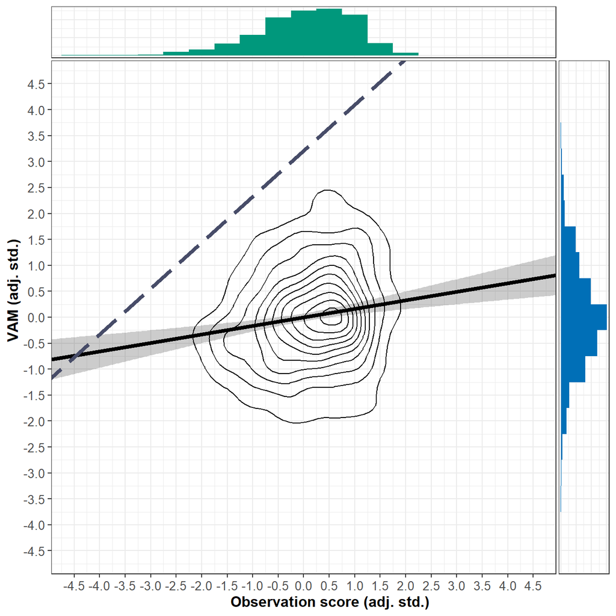

#### **Figure**

#### *NCA Plot: FFT indicators - VA_MATH_adj_std*

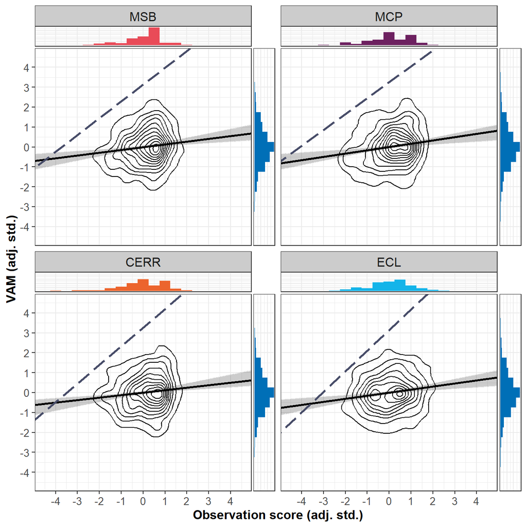

Bottlenecks (expressed as actual values)

| VA_MATH_adj_std | cr_fdh FFT_CEV_adj_std | cr_fdh FFT_MSB_adj_std | cr_fdh FFT_MCP_adj_std | cr_fdh FFT_CERR_adj_std | cr_fdh FFT_ECL_adj_std |
| --- | --- | --- | --- | --- | --- |
| -3.5 | NN | NN | NN | NN | NN |
| -3.0 | NN | NN | NN | NN | NN |
| -2.5 | NN | NN | NN | NN | NN |
| -2.0 | NN | NN | NN | NN | NN |
| -1.5 | NN | NN | NN | NN | NN |
| -1.0 | NN | NN | NN | NN | -4.011 |
| -0.5 | -4.208 | NN | -4.699 | -4.026 | -3.527 |
| 0.0 | -3.643 | -3.723 | -4.074 | -3.491 | -3.043 |
| 0.5 | -3.078 | -3.130 | -3.448 | -2.956 | -2.559 |
| 1.0 | -2.513 | -2.537 | -2.823 | -2.421 | -2.075 |
| 1.5 | -1.948 | -1.945 | -2.197 | -1.886 | -1.591 |
| 2.0 | -1.383 | -1.352 | -1.572 | -1.351 | -1.108 |
| 2.5 | -0.818 | -0.759 | -0.946 | -0.816 | -0.624 |
| 3.0 | -0.252 | -0.167 | -0.321 | -0.281 | -0.140 |

Note. Data from 642 classrooms is included. NN = Not necessary.

Bottlenecks (expressed as percentage range)

| VA_MATH_adj_std | cr_fdh FFT_CEV_adj_std | cr_fdh FFT_MSB_adj_std | cr_fdh FFT_MCP_adj_std | cr_fdh FFT_CERR_adj_std | cr_fdh FFT_ECL_adj_std |
| --- | --- | --- | --- | --- | --- |
| -3.5 | NN | NN | NN | NN | NN |
| -3.0 | NN | NN | NN | NN | NN |
| -2.5 | NN | NN | NN | NN | NN |
| -2.0 | NN | NN | NN | NN | NN |
| -1.5 | NN | NN | NN | NN | NN |
| -1.0 | NN | NN | NN | NN | 0.4 |
| -0.5 | 7.2 | NN | 2.4 | 3.0 | 7.3 |
| 0.0 | 15.6 | 7.5 | 11.2 | 11.5 | 14.1 |
| 0.5 | 24.0 | 16.8 | 20.0 | 20.0 | 21.0 |
| 1.0 | 32.4 | 26.2 | 28.9 | 28.5 | 27.8 |
| 1.5 | 40.8 | 35.5 | 37.7 | 36.9 | 34.7 |
| 2.0 | 49.1 | 44.8 | 46.5 | 45.4 | 41.5 |
| 2.5 | 57.5 | 54.1 | 55.4 | 53.9 | 48.4 |
| 3.0 | 65.9 | 63.4 | 64.2 | 62.4 | 55.2 |

Note. Data from 642 classrooms is included. NN = Not necessary.

Bottlenecks (expressed as percentiles)

| VA_MATH_adj_std | cr_fdh FFT_CEV_adj_std | cr_fdh FFT_MSB_adj_std | cr_fdh FFT_MCP_adj_std | cr_fdh FFT_CERR_adj_std | cr_fdh FFT_ECL_adj_std |
| --- | --- | --- | --- | --- | --- |
| -3.5 | NN | NN | NN | NN | NN |
| -3.0 | NN | NN | NN | NN | NN |
| -2.5 | NN | NN | NN | NN | NN |
| -2.0 | NN | NN | NN | NN | NN |
| -1.5 | NN | NN | NN | NN | NN |
| -1.0 | NN | NN | NN | NN | 0.2 |
| -0.5 | 0.3 | NN | 0.2 | 0.2 | 0.3 |
| 0.0 | 0.5 | 0.5 | 0.3 | 0.6 | 0.3 |
| 0.5 | 0.8 | 1.6 | 0.3 | 0.9 | 1.1 |
| 1.0 | 2.2 | 2.5 | 1.2 | 2.3 | 1.4 |
| 1.5 | 4.0 | 5.5 | 1.9 | 4.7 | 4.7 |
| 2.0 | 9.3 | 12.5 | 8.9 | 9.5 | 13.7 |
| 2.5 | 18.4 | 17.0 | 18.5 | 18.8 | 29.6 |
| 3.0 | 35.8 | 31.3 | 32.1 | 36.0 | 41.7 |

Note. Data from 642 classrooms is included. NN = Not necessary.

### Balanced assessment of maths (std.)

OLS coefficients

| Domain | Coefficient | Item | Estimate | Std. Error | t value | p value |
| --- | --- | --- | --- | --- | --- | --- |
| FFT_CEV_adj_std | Intercept | CEV | 0.000 | 0.039 | 0.000 | 1.000 |
| FFT_CEV_adj_std | Beta | CEV | 0.116 | 0.039 | 2.967 | 0.003 |
| FFT_MSB_adj_std | Intercept | MSB | 0.000 | 0.039 | 0.000 | 1.000 |
| FFT_MSB_adj_std | Beta | MSB | 0.132 | 0.039 | 3.376 | 0.001 |
| FFT_MCP_adj_std | Intercept | MCP | 0.000 | 0.039 | 0.000 | 1.000 |
| FFT_MCP_adj_std | Beta | MCP | 0.055 | 0.039 | 1.385 | 0.166 |
| FFT_CERR_adj_std | Intercept | CERR | 0.000 | 0.039 | 0.000 | 1.000 |
| FFT_CERR_adj_std | Beta | CERR | 0.098 | 0.039 | 2.481 | 0.013 |
| FFT_ECL_adj_std | Intercept | ECL | 0.000 | 0.039 | 0.000 | 1.000 |
| FFT_ECL_adj_std | Beta | ECL | 0.120 | 0.039 | 3.064 | 0.002 |
| All | Intercept |  | 0.000 | 0.039 | 0.000 | 1.000 |
| All | Beta | MSB | 0.195 | 0.069 | 2.810 | 0.005 |
| All | Beta | MCP | -0.143 | 0.065 | -2.218 | 0.027 |
| All | Beta | CERR | -0.031 | 0.070 | -0.437 | 0.662 |
| All | Beta | ECL | 0.110 | 0.059 | 1.861 | 0.063 |

Note. Data from 642 classrooms is included.

NCA parameters

| Parameter | FFT_CEV_adj_std cr_fdh | FFT_MSB_adj_std cr_fdh | FFT_MCP_adj_std cr_fdh | FFT_CERR_adj_std cr_fdh | FFT_ECL_adj_std cr_fdh |
| --- | --- | --- | --- | --- | --- |
| Number of observations | 642 | 642 | 642 | 642 | 642 |
| Scope | 48.36885 | 45.62785 | 50.7746 | 45.26761 | 50.71657 |
| Ceiling zone | 11.33974 | 6.642581 | 10.36495 | 10.30654 | 10.97901 |
| Effect size | 0.234443 | 0.1455817 | 0.2041366 | 0.2276803 | 0.2164778 |
| Slope | 0.990871 | 1.230546 | 1.325998 | 0.9938892 | 0.8848955 |
| Intercept | 3.772585 | 4.985466 | 5.069257 | 3.524621 | 3.028417 |
| p-value | 0.1316868 | 0.6745325 | 0.4053595 | 0.05189481 | 0.01949805 |
| p-accuracy | 0.006627618 | 0.009183396 | 0.009622668 | 0.004347487 | 0.002709991 |
| Complexity | 1 | 1 | 1 | 1 | 1 |
| Fit | 90.13753 | 75.24446 | 90.29144 | 91.38496 | 90.90839 |
| Ceiling accuracy | 99.22118 | 99.68847 | 99.53271 | 99.68847 | 99.37695 |
| Accuracy nof | 637 | 640 | 639 | 640 | 638 |
| Noise | 0.8 | 0.3 | 0.3 | 0.3 | 0.6 |
| Noise nof | 5 | 2 | 2 | 2 | 4 |
| Exceptions | 0 | 0 | 0.2 | 0 | 0 |
| Exceptions nof | 0 | 0 | 1 | 0 | 0 |
| Support | 6.5 | 1.4 | 2.8 | 9.7 | 12.6 |
| Support nof | 42 | 9 | 18 | 62 | 81 |
| Spread | 0.34 | 0.4 | 0.33 | 0.3 | 0.27 |
| Sharpness | 0.89 | 0.78 | 0.9 | 0.97 | 0.95 |
| Abs. ineff. | 25.68937 | 32.34269 | 30.04469 | 24.65453 | 28.75854 |
| Rel. ineff. | 53.11139 | 70.88366 | 59.17268 | 54.46394 | 56.70443 |
| Condition ineff. | 29.05397 | 48.34761 | 44.14441 | 27.83929 | 29.54908 |
| Outcome ineff. | 33.90947 | 43.63021 | 26.90557 | 36.89633 | 38.54506 |

Note. Data from 642 classrooms is included.  
This table was saved as coef_NCA_Y2_FFT_adj_std_VA_BAM_std.csv

#### **Figure**

#### *NCA Plot: FFT_CEV_adj_std - VA_BAM_std*

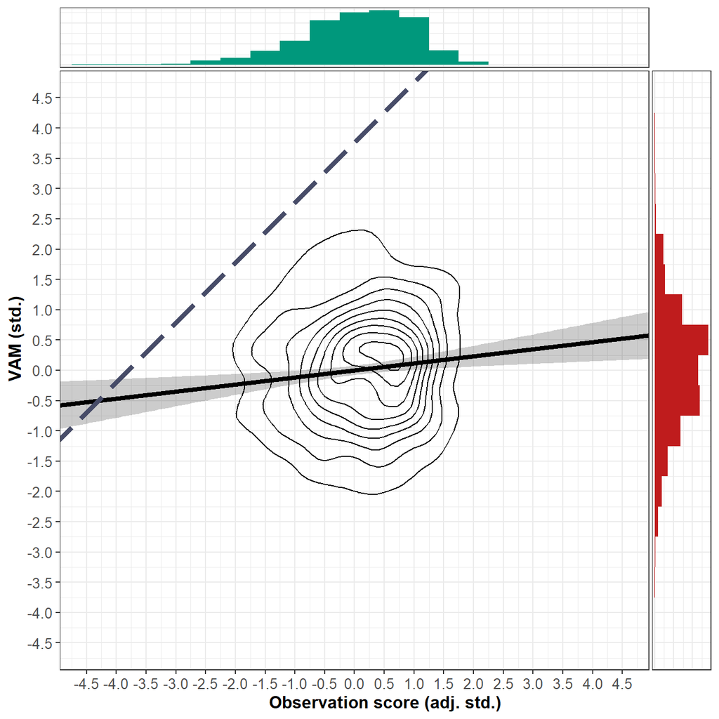